# DSC 478 Programming Machine Learning Applications

## Final Project - Spotify Data Analysis

### Name: Chien Lin Yang

### Student ID: 2031615

### Date: 16/11/2022

### 1. Data Preprocessing

```python
import numpy as np
import pandas as pd
import matplotlib.pyplot as plt
import pylab as pl
%matplotlib inline
```

#### 1-1. Data Cleaning

```python
music = pd.read_csv("music_genre.csv")
music = music.drop(['instance_id', 'artist_name', 'track_name', 'obtained_date'], axis=1)
print(music.shape)
music.head()
```

```
(50005, 14)
```

|  | popularity | acousticness | danceability | duration_ms | energy | instrumentalness | key | liveness | loudness | mode | speechiness | tempo | valence | music_genre |
| --- | --- | --- | --- | --- | --- | --- | --- | --- | --- | --- | --- | --- | --- | --- |
| 0 | 27.0 | 0.00468 | 0.652 | -1.0 | 0.941 | 0.79200 | A# | 0.115 | -5.201 | Minor | 0.0748 | 100.889 | 0.759 | Electronic |
| 1 | 31.0 | 0.01270 | 0.622 | 218293.0 | 0.890 | 0.95000 | D | 0.124 | -7.043 | Minor | 0.0300 | 115.00200000000001 | 0.531 | Electronic |
| 2 | 28.0 | 0.00306 | 0.620 | 215613.0 | 0.755 | 0.01180 | G# | 0.534 | -4.617 | Major | 0.0345 | 127.994 | 0.333 | Electronic |
| 3 | 34.0 | 0.02540 | 0.774 | 166875.0 | 0.700 | 0.00253 | C# | 0.157 | -4.498 | Major | 0.2390 | 128.014 | 0.270 | Electronic |
| 4 | 32.0 | 0.00465 | 0.638 | 222369.0 | 0.587 | 0.90900 | F# | 0.157 | -6.266 | Major | 0.0413 | 145.036 | 0.323 | Electronic |

```python
music.info()
```

```
<class 'pandas.core.frame.DataFrame'>
RangeIndex: 50005 entries, 0 to 50004
Data columns (total 14 columns):
 #   Column            Non-Null Count  Dtype
---  ------            --------------  -----
 0   popularity        50000 non-null  float64
 1   acousticness      50000 non-null  float64
 2   danceability      50000 non-null  float64
 3   duration_ms       50000 non-null  float64
 4   energy            50000 non-null  float64
 5   instrumentalness  50000 non-null  float64
 6   key               50000 non-null  object
 7   liveness          50000 non-null  float64
 8   loudness          50000 non-null  float64
 9   mode              50000 non-null  object
 10  speechiness       50000 non-null  float64
 11  tempo             50000 non-null  object
 12  valence           50000 non-null  float64
 13  music_genre       50000 non-null  object
dtypes: float64(10), object(4)
memory usage: 5.3+ MB
```

```python
# show the missing data
music[music.popularity.isnull()] # no information in all rows
```

|  | popularity | acousticness | danceability | duration_ms | energy | instrumentalness | key | liveness | loudness | mode | speechiness | tempo | valence | music_genre |
| --- | --- | --- | --- | --- | --- | --- | --- | --- | --- | --- | --- | --- | --- | --- |
| 10000 | NaN | NaN | NaN | NaN | NaN | NaN | NaN | NaN | NaN | NaN | NaN | NaN | NaN | NaN |
| 10001 | NaN | NaN | NaN | NaN | NaN | NaN | NaN | NaN | NaN | NaN | NaN | NaN | NaN | NaN |
| 10002 | NaN | NaN | NaN | NaN | NaN | NaN | NaN | NaN | NaN | NaN | NaN | NaN | NaN | NaN |
| 10003 | NaN | NaN | NaN | NaN | NaN | NaN | NaN | NaN | NaN | NaN | NaN | NaN | NaN | NaN |
| 10004 | NaN | NaN | NaN | NaN | NaN | NaN | NaN | NaN | NaN | NaN | NaN | NaN | NaN | NaN |

```python
#drop all rows without any information
music.dropna(axis=0, inplace=True)
music.shape
```

```
(50000, 14)
```

```python
music.info()
```

```
<class 'pandas.core.frame.DataFrame'>
Int64Index: 50000 entries, 0 to 50004
Data columns (total 14 columns):
 #   Column            Non-Null Count  Dtype
---  ------            --------------  -----
 0   popularity        50000 non-null  float64
 1   acousticness      50000 non-null  float64
 2   danceability      50000 non-null  float64
 3   duration_ms       50000 non-null  float64
 4   energy            50000 non-null  float64
 5   instrumentalness  50000 non-null  float64
 6   key               50000 non-null  object
 7   liveness          50000 non-null  float64
 8   loudness          50000 non-null  float64
 9   mode              50000 non-null  object
 10  speechiness       50000 non-null  float64
 11  tempo             50000 non-null  object
 12  valence           50000 non-null  float64
 13  music_genre       50000 non-null  object
dtypes: float64(10), object(4)
memory usage: 5.7+ MB
```

```python
music.describe(include="all")
```

|  | popularity | acousticness | danceability | duration_ms | energy | instrumentalness | key | liveness | loudness | mode | speechiness | tempo | valence | music_genre |
| --- | --- | --- | --- | --- | --- | --- | --- | --- | --- | --- | --- | --- | --- | --- |
| count | 50000.000000 | 50000.000000 | 50000.000000 | 5.000000e+04 | 50000.000000 | 50000.000000 | 50000 | 50000.000000 | 50000.000000 | 50000 | 50000.000000 | 50000 | 50000.000000 | 50000 |
| unique | NaN | NaN | NaN | NaN | NaN | NaN | 12 | NaN | NaN | 2 | NaN | 29394 | NaN | 10 |
| top | NaN | NaN | NaN | NaN | NaN | NaN | G | NaN | NaN | Major | NaN | ? | NaN | Electronic |
| freq | NaN | NaN | NaN | NaN | NaN | NaN | 5727 | NaN | NaN | 32099 | NaN | 4980 | NaN | 5000 |
| mean | 44.220420 | 0.306383 | 0.558241 | 2.212526e+05 | 0.599755 | 0.181601 | NaN | 0.193896 | -9.133761 | NaN | 0.093586 | NaN | 0.456264 | NaN |
| std | 15.542008 | 0.341340 | 0.178632 | 1.286720e+05 | 0.264559 | 0.325409 | NaN | 0.161637 | 6.162990 | NaN | 0.101373 | NaN | 0.247119 | NaN |
| min | 0.000000 | 0.000000 | 0.059600 | -1.000000e+00 | 0.000792 | 0.000000 | NaN | 0.009670 | -47.046000 | NaN | 0.022300 | NaN | 0.000000 | NaN |
| 25% | 34.000000 | 0.020000 | 0.442000 | 1.748000e+05 | 0.433000 | 0.000000 | NaN | 0.096900 | -10.860000 | NaN | 0.036100 | NaN | 0.257000 | NaN |
| 50% | 45.000000 | 0.144000 | 0.568000 | 2.192810e+05 | 0.643000 | 0.000158 | NaN | 0.126000 | -7.276500 | NaN | 0.048900 | NaN | 0.448000 | NaN |
| 75% | 56.000000 | 0.552000 | 0.687000 | 2.686122e+05 | 0.815000 | 0.155000 | NaN | 0.244000 | -5.173000 | NaN | 0.098525 | NaN | 0.648000 | NaN |
| max | 99.000000 | 0.996000 | 0.986000 | 4.830606e+06 | 0.999000 | 0.996000 | NaN | 1.000000 | 3.744000 | NaN | 0.942000 | NaN | 0.992000 | NaN |

```python
music['tempo'].describe()
```

```
count     50000
unique    29394
top           ?
freq       4980
Name: tempo, dtype: object
```

```python
# Replace the special character '?' with the null values
music['tempo'] = music['tempo'].replace('?', np.NaN)
```

```python
# Cover 'tempo' to the appropriate type so that we can calculate the mean of 'tempo'
music['tempo'] = music['tempo'].astype(float)

# handle missing values by imputing those values based on variable means
tempo_mean = music.tempo.mean()
music.tempo.fillna(tempo_mean, axis=0, inplace=True)
```

```python
music.describe(include="all").T
```

|  | count | unique | top | freq | mean | std | min | 25% | 50% | 75% | max |
| --- | --- | --- | --- | --- | --- | --- | --- | --- | --- | --- | --- |
| popularity | 50000.0 | NaN | NaN | NaN | 44.22042 | 15.542008 | 0.0 | 34.0 | 45.0 | 56.0 | 99.0 |
| acousticness | 50000.0 | NaN | NaN | NaN | 0.306383 | 0.34134 | 0.0 | 0.02 | 0.144 | 0.552 | 0.996 |
| danceability | 50000.0 | NaN | NaN | NaN | 0.558241 | 0.178632 | 0.0596 | 0.442 | 0.568 | 0.687 | 0.986 |
| duration_ms | 50000.0 | NaN | NaN | NaN | 221252.60286 | 128671.957157 | -1.0 | 174800.0 | 219281.0 | 268612.25 | 4830606.0 |
| energy | 50000.0 | NaN | NaN | NaN | 0.599755 | 0.264559 | 0.000792 | 0.433 | 0.643 | 0.815 | 0.999 |
| instrumentalness | 50000.0 | NaN | NaN | NaN | 0.181601 | 0.325409 | 0.0 | 0.0 | 0.000158 | 0.155 | 0.996 |
| key | 50000 | 12 | G | 5727 | NaN | NaN | NaN | NaN | NaN | NaN | NaN |
| liveness | 50000.0 | NaN | NaN | NaN | 0.193896 | 0.161637 | 0.00967 | 0.0969 | 0.126 | 0.244 | 1.0 |
| loudness | 50000.0 | NaN | NaN | NaN | -9.133761 | 6.16299 | -47.046 | -10.86 | -7.2765 | -5.173 | 3.744 |
| mode | 50000 | 2 | Major | 32099 | NaN | NaN | NaN | NaN | NaN | NaN | NaN |
| speechiness | 50000.0 | NaN | NaN | NaN | 0.093586 | 0.101373 | 0.0223 | 0.0361 | 0.0489 | 0.098525 | 0.942 |
| tempo | 50000.0 | NaN | NaN | NaN | 119.952961 | 29.075697 | 34.347 | 96.77575 | 119.952961 | 139.46825 | 220.276 |
| valence | 50000.0 | NaN | NaN | NaN | 0.456264 | 0.247119 | 0.0 | 0.257 | 0.448 | 0.648 | 0.992 |
| music_genre | 50000 | 10 | Electronic | 5000 | NaN | NaN | NaN | NaN | NaN | NaN | NaN |

#### 1-2. Data Merging

```python
# merge the two columns: 'key' and 'mode', and then remove the two columns
music['keyMode'] = (music['key'] + ' ' + music['mode'])
music = music.drop(columns=['key', 'mode'])
music.head()
```

|  | popularity | acousticness | danceability | duration_ms | energy | instrumentalness | liveness | loudness | speechiness | tempo | valence | music_genre | keyMode |
| --- | --- | --- | --- | --- | --- | --- | --- | --- | --- | --- | --- | --- | --- |
| 0 | 27.0 | 0.00468 | 0.652 | -1.0 | 0.941 | 0.79200 | 0.115 | -5.201 | 0.0748 | 100.889 | 0.759 | Electronic | A# Minor |
| 1 | 31.0 | 0.01270 | 0.622 | 218293.0 | 0.890 | 0.95000 | 0.124 | -7.043 | 0.0300 | 115.002 | 0.531 | Electronic | D Minor |
| 2 | 28.0 | 0.00306 | 0.620 | 215613.0 | 0.755 | 0.01180 | 0.534 | -4.617 | 0.0345 | 127.994 | 0.333 | Electronic | G# Major |
| 3 | 34.0 | 0.02540 | 0.774 | 166875.0 | 0.700 | 0.00253 | 0.157 | -4.498 | 0.2390 | 128.014 | 0.270 | Electronic | C# Major |
| 4 | 32.0 | 0.00465 | 0.638 | 222369.0 | 0.587 | 0.90900 | 0.157 | -6.266 | 0.0413 | 145.036 | 0.323 | Electronic | F# Major |

### 2. Data Exploration and Visualization

```python
music.describe(include="all").T
```

|  | count | unique | top | freq | mean | std | min | 25% | 50% | 75% | max |
| --- | --- | --- | --- | --- | --- | --- | --- | --- | --- | --- | --- |
| popularity | 50000.0 | NaN | NaN | NaN | 44.22042 | 15.542008 | 0.0 | 34.0 | 45.0 | 56.0 | 99.0 |
| acousticness | 50000.0 | NaN | NaN | NaN | 0.306383 | 0.34134 | 0.0 | 0.02 | 0.144 | 0.552 | 0.996 |
| danceability | 50000.0 | NaN | NaN | NaN | 0.558241 | 0.178632 | 0.0596 | 0.442 | 0.568 | 0.687 | 0.986 |
| duration_ms | 50000.0 | NaN | NaN | NaN | 221252.60286 | 128671.957157 | -1.0 | 174800.0 | 219281.0 | 268612.25 | 4830606.0 |
| energy | 50000.0 | NaN | NaN | NaN | 0.599755 | 0.264559 | 0.000792 | 0.433 | 0.643 | 0.815 | 0.999 |
| instrumentalness | 50000.0 | NaN | NaN | NaN | 0.181601 | 0.325409 | 0.0 | 0.0 | 0.000158 | 0.155 | 0.996 |
| liveness | 50000.0 | NaN | NaN | NaN | 0.193896 | 0.161637 | 0.00967 | 0.0969 | 0.126 | 0.244 | 1.0 |
| loudness | 50000.0 | NaN | NaN | NaN | -9.133761 | 6.16299 | -47.046 | -10.86 | -7.2765 | -5.173 | 3.744 |
| speechiness | 50000.0 | NaN | NaN | NaN | 0.093586 | 0.101373 | 0.0223 | 0.0361 | 0.0489 | 0.098525 | 0.942 |
| tempo | 50000.0 | NaN | NaN | NaN | 119.952961 | 29.075697 | 34.347 | 96.77575 | 119.952961 | 139.46825 | 220.276 |
| valence | 50000.0 | NaN | NaN | NaN | 0.456264 | 0.247119 | 0.0 | 0.257 | 0.448 | 0.648 | 0.992 |
| music_genre | 50000 | 10 | Electronic | 5000 | NaN | NaN | NaN | NaN | NaN | NaN | NaN |
| keyMode | 50000 | 24 | G Major | 4332 | NaN | NaN | NaN | NaN | NaN | NaN | NaN |

```python
music.info()
```

```
<class 'pandas.core.frame.DataFrame'>
Int64Index: 50000 entries, 0 to 50004
Data columns (total 13 columns):
 #   Column            Non-Null Count  Dtype
---  ------            --------------  -----
 0   popularity        50000 non-null  float64
 1   acousticness      50000 non-null  float64
 2   danceability      50000 non-null  float64
 3   duration_ms       50000 non-null  float64
 4   energy            50000 non-null  float64
 5   instrumentalness  50000 non-null  float64
 6   liveness          50000 non-null  float64
 7   loudness          50000 non-null  float64
 8   speechiness       50000 non-null  float64
 9   tempo             50000 non-null  float64
 10  valence           50000 non-null  float64
 11  music_genre       50000 non-null  object
 12  keyMode           50000 non-null  object
dtypes: float64(11), object(2)
memory usage: 5.3+ MB
```

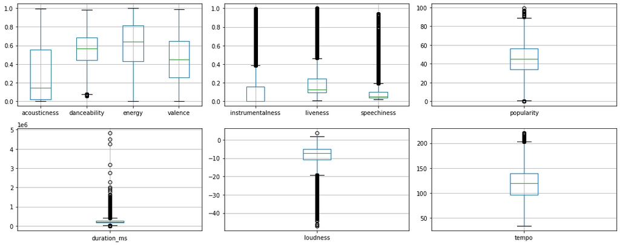

```python
# For the numeric attributes, display box plots
fig = plt.figure(figsize=(15,6))
ax1 = fig.add_subplot(231)
music.boxplot(column=['acousticness', 'danceability', 'energy', 'valence'], return_type="axes")

ax1 = fig.add_subplot(232)
music.boxplot(column=['instrumentalness', 'liveness', 'speechiness'], return_type="axes")

ax1 = fig.add_subplot(233)
music.boxplot(column=['popularity'], return_type="axes")

ax1 = fig.add_subplot(234)
music.boxplot(column=['duration_ms'], return_type="axes")

ax1 = fig.add_subplot(235)
music.boxplot(column=['loudness'], return_type="axes")

ax1 = fig.add_subplot(236)
music.boxplot(column=['tempo'], return_type="axes")

fig.tight_layout()
plt.show()
```

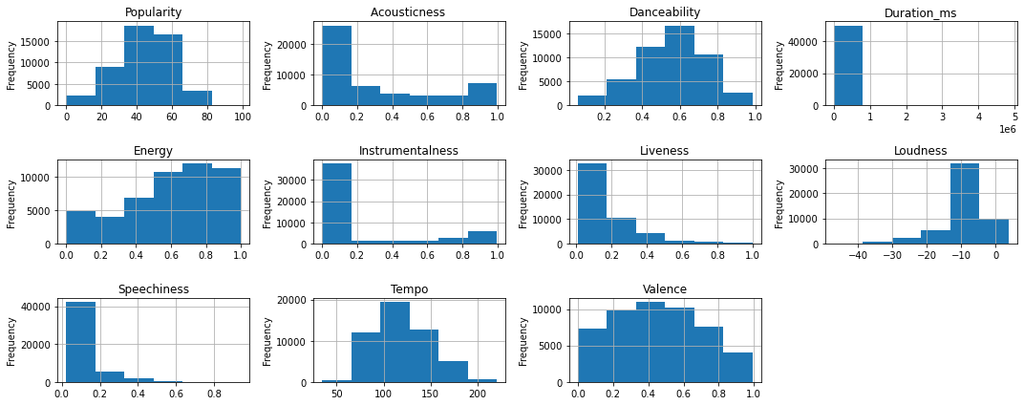

```python
# For the numeric attributes, display histograms
fig = plt.figure(figsize=(15,6))
ax1 = fig.add_subplot(341)
ax1.set_title("Popularity")
music["popularity"].plot(kind="hist", bins=6, grid=True)

ax1 = fig.add_subplot(342)
ax1.set_title("Acousticness ")
music["acousticness"].plot(kind="hist", bins=6, grid=True)

ax1 = fig.add_subplot(343)
ax1.set_title("Danceability")
music["danceability"].plot(kind="hist", bins=6, grid=True)

ax1 = fig.add_subplot(344)
ax1.set_title("Duration_ms")
music["duration_ms"].plot(kind="hist", bins=6, grid=True)

ax1 = fig.add_subplot(345)
ax1.set_title("Energy")
music["energy"].plot(kind="hist", bins=6, grid=True)

ax1 = fig.add_subplot(346)
ax1.set_title("Instrumentalness")
music["instrumentalness"].plot(kind="hist", bins=6, grid=True)

ax1 = fig.add_subplot(347)
ax1.set_title("Liveness")
music["liveness"].plot(kind="hist", bins=6, grid=True)

ax1 = fig.add_subplot(348)
ax1.set_title("Loudness")
music["loudness"].plot(kind="hist", bins=6, grid=True)

ax1 = fig.add_subplot(349)
ax1.set_title("Speechiness")
music["speechiness"].plot(kind="hist", bins=6, grid=True)

ax1 = fig.add_subplot(3,4,10)
ax1.set_title("Tempo")
music["tempo"].plot(kind="hist", bins=6, grid=True)

ax1 = fig.add_subplot(3,4,11)
ax1.set_title("Valence")
music["valence"].plot(kind="hist", bins=6, grid=True)

fig.tight_layout()
plt.show()
```

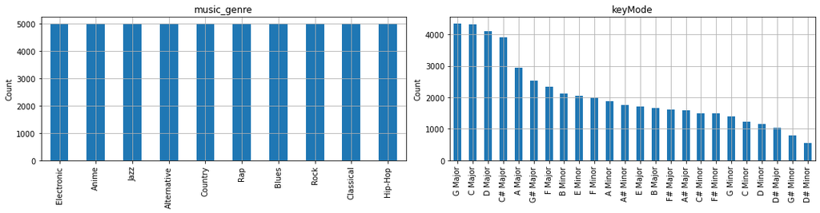

```python
# For the categorical attributes, display bar charts
fig = plt.figure(figsize=(15,4))
ax1 = fig.add_subplot(121)
ax1.set_ylabel('Count')
ax1.set_title('music_genre')
music['music_genre'].value_counts().plot(kind='bar', grid = True)

ax1 = fig.add_subplot(122)
ax1.set_ylabel('Count')
ax1.set_title("keyMode")
music['keyMode'].value_counts().plot(kind='bar', grid = True)

fig.tight_layout()
plt.show()
```

```python
# correlation analysis
pd.options.display.float_format='{:,.2f}'.format
music[['popularity', 'acousticness', 'danceability', 'duration_ms', 'energy', 'instrumentalness', 'liveness', 'loudness', 'speechiness', 'tempo', 'valence']].corr()
```

|  | popularity | acousticness | danceability | duration_ms | energy | instrumentalness | liveness | loudness | speechiness | tempo | valence |
| --- | --- | --- | --- | --- | --- | --- | --- | --- | --- | --- | --- |
| popularity | 1.00 | -0.29 | 0.36 | -0.08 | 0.22 | -0.36 | -0.04 | 0.32 | 0.22 | 0.03 | 0.12 |
| acousticness | -0.29 | 1.00 | -0.35 | 0.06 | -0.79 | 0.39 | -0.11 | -0.73 | -0.16 | -0.22 | -0.27 |
| danceability | 0.36 | -0.35 | 1.00 | -0.16 | 0.26 | -0.30 | -0.05 | 0.39 | 0.28 | -0.01 | 0.43 |
| duration_ms | -0.08 | 0.06 | -0.16 | 1.00 | -0.07 | 0.13 | 0.02 | -0.10 | -0.08 | -0.04 | -0.13 |
| energy | 0.22 | -0.79 | 0.26 | -0.07 | 1.00 | -0.39 | 0.19 | 0.84 | 0.16 | 0.25 | 0.40 |
| instrumentalness | -0.36 | 0.39 | -0.30 | 0.13 | -0.39 | 1.00 | -0.09 | -0.53 | -0.20 | -0.12 | -0.27 |
| liveness | -0.04 | -0.11 | -0.05 | 0.02 | 0.19 | -0.09 | 1.00 | 0.13 | 0.11 | 0.04 | 0.05 |
| loudness | 0.32 | -0.73 | 0.39 | -0.10 | 0.84 | -0.53 | 0.13 | 1.00 | 0.17 | 0.23 | 0.34 |
| speechiness | 0.22 | -0.16 | 0.28 | -0.08 | 0.16 | -0.20 | 0.11 | 0.17 | 1.00 | 0.06 | 0.06 |
| tempo | 0.03 | -0.22 | -0.01 | -0.04 | 0.25 | -0.12 | 0.04 | 0.23 | 0.06 | 1.00 | 0.10 |
| valence | 0.12 | -0.27 | 0.43 | -0.13 | 0.40 | -0.27 | 0.05 | 0.34 | 0.06 | 0.10 | 1.00 |

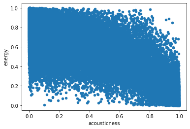

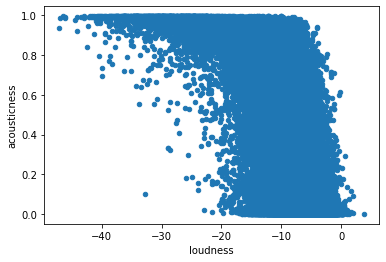

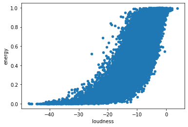

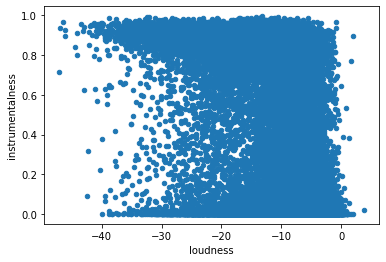

```python
music.plot(x="acousticness", y="energy", kind="scatter")
music.plot(x="loudness", y="acousticness", kind="scatter")
music.plot(x="loudness", y="energy", kind="scatter")
music.plot(x="loudness", y="instrumentalness", kind="scatter")
```

#### Since target attribute is 'popularity', we need to convert the numeric attribute to categorical attribute for classification and clustering.

```python
musicClass = music.copy()
print(musicClass.shape)
musicClass.head(6)
```

```
(50000, 13)
```

|  | popularity | acousticness | danceability | duration_ms | energy | instrumentalness | liveness | loudness | speechiness | tempo | valence | music_genre | keyMode |
| --- | --- | --- | --- | --- | --- | --- | --- | --- | --- | --- | --- | --- | --- |
| 0 | 27.00 | 0.00 | 0.65 | -1.00 | 0.94 | 0.79 | 0.12 | -5.20 | 0.07 | 100.89 | 0.76 | Electronic | A# Minor |
| 1 | 31.00 | 0.01 | 0.62 | 218,293.00 | 0.89 | 0.95 | 0.12 | -7.04 | 0.03 | 115.00 | 0.53 | Electronic | D Minor |
| 2 | 28.00 | 0.00 | 0.62 | 215,613.00 | 0.76 | 0.01 | 0.53 | -4.62 | 0.03 | 127.99 | 0.33 | Electronic | G# Major |
| 3 | 34.00 | 0.03 | 0.77 | 166,875.00 | 0.70 | 0.00 | 0.16 | -4.50 | 0.24 | 128.01 | 0.27 | Electronic | C# Major |
| 4 | 32.00 | 0.00 | 0.64 | 222,369.00 | 0.59 | 0.91 | 0.16 | -6.27 | 0.04 | 145.04 | 0.32 | Electronic | F# Major |
| 5 | 47.00 | 0.01 | 0.76 | 519,468.00 | 0.73 | 0.85 | 0.22 | -10.52 | 0.04 | 119.95 | 0.61 | Electronic | D Minor |

```python
musicClass['popularity'].describe()
```

```
count   50,000.00
mean        44.22
std         15.54
min          0.00
25%         34.00
50%         45.00
75%         56.00
max         99.00
Name: popularity, dtype: float64
```

```python
pop_mean = musicClass['popularity'].mean()
musicClass = musicClass.assign(popClass=pd.cut(musicClass['popularity'] ,
                                               bins=[-1, pop_mean, 100],
                                               labels=['Unpopular', 'Popular']))
musicClass = musicClass.drop(columns ='popularity')
musicClass.head(6)
```

|  | acousticness | danceability | duration_ms | energy | instrumentalness | liveness | loudness | speechiness | tempo | valence | music_genre | keyMode | popClass |
| --- | --- | --- | --- | --- | --- | --- | --- | --- | --- | --- | --- | --- | --- |
| 0 | 0.00 | 0.65 | -1.00 | 0.94 | 0.79 | 0.12 | -5.20 | 0.07 | 100.89 | 0.76 | Electronic | A# Minor | Unpopular |
| 1 | 0.01 | 0.62 | 218,293.00 | 0.89 | 0.95 | 0.12 | -7.04 | 0.03 | 115.00 | 0.53 | Electronic | D Minor | Unpopular |
| 2 | 0.00 | 0.62 | 215,613.00 | 0.76 | 0.01 | 0.53 | -4.62 | 0.03 | 127.99 | 0.33 | Electronic | G# Major | Unpopular |
| 3 | 0.03 | 0.77 | 166,875.00 | 0.70 | 0.00 | 0.16 | -4.50 | 0.24 | 128.01 | 0.27 | Electronic | C# Major | Unpopular |
| 4 | 0.00 | 0.64 | 222,369.00 | 0.59 | 0.91 | 0.16 | -6.27 | 0.04 | 145.04 | 0.32 | Electronic | F# Major | Unpopular |
| 5 | 0.01 | 0.76 | 519,468.00 | 0.73 | 0.85 | 0.22 | -10.52 | 0.04 | 119.95 | 0.61 | Electronic | D Minor | Popular |

```python
p1 = pd.crosstab(musicClass["music_genre"], musicClass["popClass"])
p1
```

| popClass music_genre | Unpopular | Popular |
| --- | --- | --- |
| Alternative | 1096 | 3904 |
| Anime | 4827 | 173 |
| Blues | 4285 | 715 |
| Classical | 4514 | 486 |
| Country | 2520 | 2480 |
| Electronic | 3853 | 1147 |
| Hip-Hop | 34 | 4966 |
| Jazz | 3424 | 1576 |
| Rap | 16 | 4984 |
| Rock | 26 | 4974 |

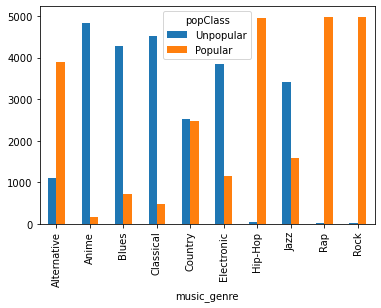

```python
plt.show(p1.plot(kind="bar"))
```

```python
p2 = pd.crosstab(musicClass["keyMode"], musicClass["popClass"])
p2.T
```

| keyMode popClass | A Major | A Minor | A# Major | A# Minor | B Major | B Minor | C Major | C Minor | C# Major | C# Minor | ... | E Major | E Minor | F Major | F Minor | F# Major | F# Minor | G Major | G Minor | G# Major | G# Minor |
| --- | --- | --- | --- | --- | --- | --- | --- | --- | --- | --- | --- | --- | --- | --- | --- | --- | --- | --- | --- | --- | --- |
| Unpopular | 1481 | 1001 | 895 | 741 | 734 | 946 | 2207 | 645 | 1625 | 596 | ... | 894 | 1029 | 1319 | 992 | 742 | 635 | 2282 | 792 | 1158 | 321 |
| Popular | 1469 | 874 | 698 | 1022 | 928 | 1181 | 2100 | 570 | 2285 | 899 | ... | 827 | 1010 | 1019 | 1011 | 877 | 847 | 2050 | 603 | 1370 | 470 |

2 rows × 24 columns

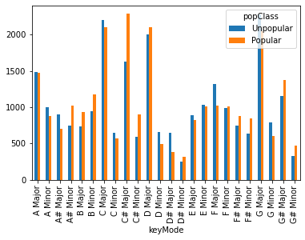

```python
plt.show(p2.plot(kind="bar"))
```

### 3. Data Preparation

#### Separate the target attribute and the attributes used for model training.

```python
mc_target = musicClass.popClass
mc_target.head()
```

```
0    Unpopular
1    Unpopular
2    Unpopular
3    Unpopular
4    Unpopular
Name: popClass, dtype: category
Categories (2, object): ['Unpopular' < 'Popular']
```

```python
mc_records = musicClass.drop(columns='popClass')
mc_records.head()
```

|  | acousticness | danceability | duration_ms | energy | instrumentalness | liveness | loudness | speechiness | tempo | valence | music_genre | keyMode |
| --- | --- | --- | --- | --- | --- | --- | --- | --- | --- | --- | --- | --- |
| 0 | 0.00 | 0.65 | -1.00 | 0.94 | 0.79 | 0.12 | -5.20 | 0.07 | 100.89 | 0.76 | Electronic | A# Minor |
| 1 | 0.01 | 0.62 | 218,293.00 | 0.89 | 0.95 | 0.12 | -7.04 | 0.03 | 115.00 | 0.53 | Electronic | D Minor |
| 2 | 0.00 | 0.62 | 215,613.00 | 0.76 | 0.01 | 0.53 | -4.62 | 0.03 | 127.99 | 0.33 | Electronic | G# Major |
| 3 | 0.03 | 0.77 | 166,875.00 | 0.70 | 0.00 | 0.16 | -4.50 | 0.24 | 128.01 | 0.27 | Electronic | C# Major |
| 4 | 0.00 | 0.64 | 222,369.00 | 0.59 | 0.91 | 0.16 | -6.27 | 0.04 | 145.04 | 0.32 | Electronic | F# Major |

#### Create dummy variables for the categorical variables.

```python
mc_matrix = pd.get_dummies(mc_records)
print(mc_matrix.shape)
mc_matrix.head()
```

```
(50000, 44)
```

|  | acousticness | danceability | duration_ms | energy | instrumentalness | liveness | loudness | speechiness | tempo | valence | ... | keyMode_E Major | keyMode_E Minor | keyMode_F Major | keyMode_F Minor | keyMode_F# Major | keyMode_F# Minor | keyMode_G Major | keyMode_G Minor | keyMode_G# Major | keyMode_G# Minor |
| --- | --- | --- | --- | --- | --- | --- | --- | --- | --- | --- | --- | --- | --- | --- | --- | --- | --- | --- | --- | --- | --- |
| 0 | 0.00 | 0.65 | -1.00 | 0.94 | 0.79 | 0.12 | -5.20 | 0.07 | 100.89 | 0.76 | ... | 0 | 0 | 0 | 0 | 0 | 0 | 0 | 0 | 0 | 0 |
| 1 | 0.01 | 0.62 | 218,293.00 | 0.89 | 0.95 | 0.12 | -7.04 | 0.03 | 115.00 | 0.53 | ... | 0 | 0 | 0 | 0 | 0 | 0 | 0 | 0 | 0 | 0 |
| 2 | 0.00 | 0.62 | 215,613.00 | 0.76 | 0.01 | 0.53 | -4.62 | 0.03 | 127.99 | 0.33 | ... | 0 | 0 | 0 | 0 | 0 | 0 | 0 | 0 | 1 | 0 |
| 3 | 0.03 | 0.77 | 166,875.00 | 0.70 | 0.00 | 0.16 | -4.50 | 0.24 | 128.01 | 0.27 | ... | 0 | 0 | 0 | 0 | 0 | 0 | 0 | 0 | 0 | 0 |
| 4 | 0.00 | 0.64 | 222,369.00 | 0.59 | 0.91 | 0.16 | -6.27 | 0.04 | 145.04 | 0.32 | ... | 0 | 0 | 0 | 0 | 1 | 0 | 0 | 0 | 0 | 0 |

5 rows × 44 columns

#### Divide the data into randomized training and test partitions

```python
from sklearn.model_selection import train_test_split
```

```python
mc_train, mc_test, mc_target_train, mc_target_test = train_test_split(mc_matrix, mc_target, test_size=0.2, random_state=33)

print(mc_test.shape)
mc_test.head()
```

```
(10000, 44)
```

|  | acousticness | danceability | duration_ms | energy | instrumentalness | liveness | loudness | speechiness | tempo | valence | ... | keyMode_E Major | keyMode_E Minor | keyMode_F Major | keyMode_F Minor | keyMode_F# Major | keyMode_F# Minor | keyMode_G Major | keyMode_G Minor | keyMode_G# Major | keyMode_G# Minor |
| --- | --- | --- | --- | --- | --- | --- | --- | --- | --- | --- | --- | --- | --- | --- | --- | --- | --- | --- | --- | --- | --- |
| 31814 | 0.55 | 0.61 | 183,027.00 | 0.30 | 0.00 | 0.04 | -11.40 | 0.04 | 100.98 | 0.46 | ... | 0 | 0 | 0 | 0 | 0 | 0 | 0 | 0 | 0 | 0 |
| 34707 | 0.61 | 0.53 | 140,560.00 | 0.47 | 0.00 | 0.06 | -9.57 | 0.19 | 185.39 | 0.89 | ... | 0 | 0 | 0 | 0 | 0 | 0 | 0 | 0 | 1 | 0 |
| 14227 | 0.40 | 0.32 | 279,798.00 | 0.64 | 0.62 | 0.07 | -7.89 | 0.04 | 119.95 | 0.26 | ... | 0 | 0 | 0 | 0 | 0 | 0 | 0 | 0 | 0 | 0 |
| 26299 | 0.23 | 0.91 | 185,866.00 | 0.60 | 0.00 | 0.09 | -4.79 | 0.23 | 111.83 | 0.25 | ... | 0 | 0 | 0 | 0 | 0 | 0 | 0 | 0 | 0 | 0 |
| 9876 | 0.41 | 0.26 | 257,600.00 | 0.90 | 0.66 | 0.07 | -7.47 | 0.07 | 167.04 | 0.23 | ... | 0 | 0 | 0 | 0 | 0 | 0 | 0 | 0 | 0 | 0 |

5 rows × 44 columns

```python
print(mc_train.shape)
mc_train.head()
```

```
(40000, 44)
```

|  | acousticness | danceability | duration_ms | energy | instrumentalness | liveness | loudness | speechiness | tempo | valence | ... | keyMode_E Major | keyMode_E Minor | keyMode_F Major | keyMode_F Minor | keyMode_F# Major | keyMode_F# Minor | keyMode_G Major | keyMode_G Minor | keyMode_G# Major | keyMode_G# Minor |
| --- | --- | --- | --- | --- | --- | --- | --- | --- | --- | --- | --- | --- | --- | --- | --- | --- | --- | --- | --- | --- | --- |
| 49244 | 0.09 | 0.85 | 156,081.00 | 0.51 | 0.00 | 0.09 | -9.69 | 0.54 | 140.06 | 0.23 | ... | 0 | 0 | 0 | 0 | 0 | 0 | 0 | 0 | 0 | 0 |
| 44929 | 0.99 | 0.49 | 353,227.00 | 0.13 | 0.82 | 0.15 | -18.83 | 0.04 | 79.52 | 0.31 | ... | 0 | 0 | 0 | 0 | 0 | 0 | 0 | 0 | 0 | 0 |
| 16474 | 0.04 | 0.44 | 244,040.00 | 0.44 | 0.02 | 0.22 | -7.85 | 0.04 | 139.69 | 0.19 | ... | 0 | 0 | 0 | 0 | 0 | 0 | 0 | 0 | 0 | 0 |
| 39553 | 0.08 | 0.61 | 350,862.00 | 0.70 | 0.00 | 0.14 | -11.34 | 0.04 | 159.83 | 0.85 | ... | 0 | 0 | 0 | 0 | 0 | 0 | 0 | 0 | 0 | 0 |
| 22970 | 0.79 | 0.55 | 247,307.00 | 0.50 | 0.08 | 0.27 | -10.09 | 0.03 | 150.77 | 0.77 | ... | 0 | 0 | 0 | 0 | 0 | 0 | 0 | 0 | 0 | 0 |

5 rows × 44 columns

#### Perform min-max normalization to rescale numeric attributes.

```python
from sklearn import preprocessing
```

```python
min_max_scaler = preprocessing.MinMaxScaler().fit(mc_train)

mc_train_norm = min_max_scaler.transform(mc_train)
mc_train_norm = pd.DataFrame(mc_train_norm, columns=mc_train.columns, index=mc_train.index)

mc_test_norm = min_max_scaler.transform(mc_test)
mc_test_norm = pd.DataFrame(mc_test_norm, columns=mc_test.columns, index=mc_test.index)
```

```python
mc_train_norm.head()
```

|  | acousticness | danceability | duration_ms | energy | instrumentalness | liveness | loudness | speechiness | tempo | valence | ... | keyMode_E Major | keyMode_E Minor | keyMode_F Major | keyMode_F Minor | keyMode_F# Major | keyMode_F# Minor | keyMode_G Major | keyMode_G Minor | keyMode_G# Major | keyMode_G# Minor |
| --- | --- | --- | --- | --- | --- | --- | --- | --- | --- | --- | --- | --- | --- | --- | --- | --- | --- | --- | --- | --- | --- |
| 49244 | 0.09 | 0.85 | 0.03 | 0.51 | 0.00 | 0.09 | 0.74 | 0.57 | 0.57 | 0.23 | ... | 0.00 | 0.00 | 0.00 | 0.00 | 0.00 | 0.00 | 0.00 | 0.00 | 0.00 | 0.00 |
| 44929 | 0.99 | 0.46 | 0.07 | 0.13 | 0.82 | 0.14 | 0.56 | 0.02 | 0.24 | 0.31 | ... | 0.00 | 0.00 | 0.00 | 0.00 | 0.00 | 0.00 | 0.00 | 0.00 | 0.00 | 0.00 |
| 16474 | 0.04 | 0.41 | 0.05 | 0.44 | 0.02 | 0.21 | 0.77 | 0.02 | 0.57 | 0.19 | ... | 0.00 | 0.00 | 0.00 | 0.00 | 0.00 | 0.00 | 0.00 | 0.00 | 0.00 | 0.00 |
| 39553 | 0.08 | 0.60 | 0.07 | 0.70 | 0.00 | 0.13 | 0.70 | 0.01 | 0.67 | 0.86 | ... | 0.00 | 0.00 | 0.00 | 0.00 | 0.00 | 0.00 | 0.00 | 0.00 | 0.00 | 0.00 |
| 22970 | 0.79 | 0.53 | 0.05 | 0.50 | 0.08 | 0.27 | 0.73 | 0.01 | 0.63 | 0.77 | ... | 0.00 | 0.00 | 0.00 | 0.00 | 0.00 | 0.00 | 0.00 | 0.00 | 0.00 | 0.00 |

5 rows × 44 columns

```python
mc_test_norm.head()
```

|  | acousticness | danceability | duration_ms | energy | instrumentalness | liveness | loudness | speechiness | tempo | valence | ... | keyMode_E Major | keyMode_E Minor | keyMode_F Major | keyMode_F Minor | keyMode_F# Major | keyMode_F# Minor | keyMode_G Major | keyMode_G Minor | keyMode_G# Major | keyMode_G# Minor |
| --- | --- | --- | --- | --- | --- | --- | --- | --- | --- | --- | --- | --- | --- | --- | --- | --- | --- | --- | --- | --- | --- |
| 31814 | 0.55 | 0.59 | 0.04 | 0.30 | 0.00 | 0.03 | 0.70 | 0.02 | 0.36 | 0.46 | ... | 0.00 | 0.00 | 0.00 | 0.00 | 0.00 | 0.00 | 0.00 | 0.00 | 0.00 | 0.00 |
| 34707 | 0.61 | 0.51 | 0.03 | 0.47 | 0.00 | 0.05 | 0.74 | 0.18 | 0.81 | 0.90 | ... | 0.00 | 0.00 | 0.00 | 0.00 | 0.00 | 0.00 | 0.00 | 0.00 | 1.00 | 0.00 |
| 14227 | 0.40 | 0.29 | 0.06 | 0.64 | 0.63 | 0.06 | 0.77 | 0.02 | 0.46 | 0.26 | ... | 0.00 | 0.00 | 0.00 | 0.00 | 0.00 | 0.00 | 0.00 | 0.00 | 0.00 | 0.00 |
| 26299 | 0.23 | 0.92 | 0.04 | 0.60 | 0.00 | 0.08 | 0.83 | 0.23 | 0.42 | 0.25 | ... | 0.00 | 0.00 | 0.00 | 0.00 | 0.00 | 0.00 | 0.00 | 0.00 | 0.00 | 0.00 |
| 9876 | 0.42 | 0.22 | 0.05 | 0.90 | 0.66 | 0.06 | 0.78 | 0.06 | 0.71 | 0.23 | ... | 0.00 | 0.00 | 0.00 | 0.00 | 0.00 | 0.00 | 0.00 | 0.00 | 0.00 | 0.00 |

5 rows × 44 columns

### 4. Classification

#### Use the KNN, decision tree, naive Bayes, classifiers from sklearn.

#### Use ensemble classifiers: Random Forest, Ada Boost, Gradient Boosted Decision Trees (GBDT), and Bagging.

### 4-1. KNN

#### Experiment with different values of K (say from 5 to 100) and the weight parameter (i.e., with or without distance weighting) to see if we can improve accuracy of the KNN classifier.

```python
from sklearn import neighbors
```

```python
knnDis = []
for K in range(5, 100):
    knnclf = neighbors.KNeighborsClassifier(K, weights='distance')
    knnclf.fit(mc_train_norm, mc_target_train)
    knnDis.append(knnclf.score(mc_test_norm, mc_target_test))
```

```python
knnUni = []
for K in range(5, 100):
    knnclf = neighbors.KNeighborsClassifier(K, weights='uniform') # weights:default=’uniform’
    knnclf.fit(mc_train_norm, mc_target_train)
    knnUni.append(knnclf.score(mc_test_norm, mc_target_test))
```

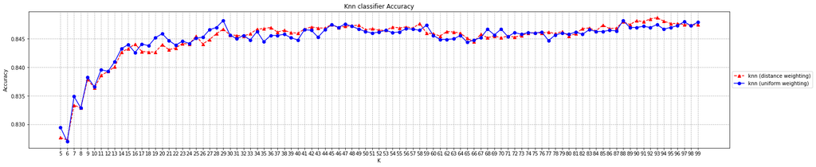

```python
Ks=list(range(5, 100))
plt.figure(figsize=(25,5))
plt.plot(Ks, knnDis, 'r^--', label='knn (distance weighting)')
plt.plot(Ks, knnUni, 'bo-', label='knn (uniform weighting)')
plt.xlabel('K')
plt.ylabel('Accuracy')
plt.title('Knn classifier Accuracy')
plt.grid(linestyle='--')
plt.xticks(Ks)
plt.legend(loc='center left', bbox_to_anchor=(1, 0.5))

plt.show()
```

```python
best_knnDis = max(knnDis)
best_knnDis_index = knnDis.index(best_knnDis)

best_knnUni = max(knnUni)
best_knnUni_index = knnUni.index(best_knnUni)

print(best_knnDis, best_knnDis_index) # K=88+5=93
print(best_knnUni, best_knnUni_index) # K=24+5=29
```

```
0.8487 88
0.8482 24
```

#### Overall, there is no significant difference between distance weighting and uniform weighting, but we choose the distance weighting with the highest correct rate. Next, using "distance" weights, compare the accuracy of the KNN classifier across the different values of K on the training and the test data to check for the potential overfitting or underfitting.

```python
knnDis_train = []
for K in range(5, 100):
    knnclf = neighbors.KNeighborsClassifier(K, weights='distance')
    knnclf.fit(mc_train_norm, mc_target_train)
    knnDis_train.append(knnclf.score(mc_train_norm, mc_target_train))
```

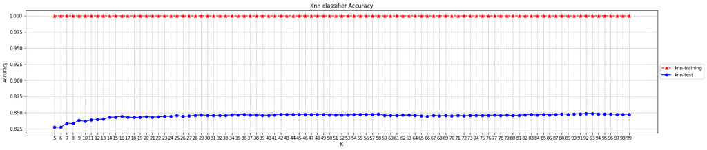

```python
Ks=list(range(5, 100))
plt.figure(figsize=(25,5))
plt.plot(Ks, knnDis_train, 'r^--', label='knn-training')
plt.plot(Ks, knnDis, 'bo-', label='knn-test')
plt.xlabel('K')
plt.ylabel('Accuracy')
plt.title('Knn classifier Accuracy')
plt.grid(linestyle='--')
plt.xticks(Ks)
plt.legend(loc='center left', bbox_to_anchor=(1, 0.5))

plt.show()
```

```python
lst = []
for i in knnDis_train:
    for j in knnDis:
        m = abs(i-j)
        lst.append((m, i, j))
min(lst)
```

```
(0.15112499999999995, 0.999825, 0.8487)
```

```python
n_neighbors = 93
knnclf = neighbors.KNeighborsClassifier(n_neighbors, weights='distance')
knnclf = knnclf.fit(mc_train_norm, mc_target_train)
```

```python
knnpreds_test = knnclf.predict(mc_test_norm)
print(knnpreds_test)
```

```
['Unpopular' 'Unpopular' 'Unpopular' ... 'Unpopular' 'Popular' 'Popular']
```

#### Evaluate KNN classifier accuracy

#### a. The classification report

```python
from sklearn.metrics import classification_report
```

```python
print(classification_report(mc_target_test, knnpreds_test))
```

```
              precision    recall  f1-score   support

     Popular       0.90      0.79      0.84      5135
   Unpopular       0.81      0.91      0.85      4865

    accuracy                           0.85     10000
   macro avg       0.85      0.85      0.85     10000
weighted avg       0.85      0.85      0.85     10000
```

#### b.The confusion matrix (visualize it using Matplotlib)

```python
from sklearn.metrics import confusion_matrix
```

```python
knncm = confusion_matrix(mc_target_test, knnpreds_test)
print(knncm)
```

```
[[4067 1068]
 [ 445 4420]]
```

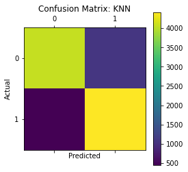

```python
plt.matshow(knncm)
plt.title('Confusion Matrix: KNN')
plt.colorbar()
plt.xlabel('Predicted')
plt.ylabel('Actual')
plt.show()
```

#### c. The average accuracy scores

```python
# training score
print('The training data score of KNN: %0.4f' % knnclf.score(mc_train_norm, mc_target_train))
# test score
print('The test data score of KNN: %0.4f' %knnclf.score(mc_test_norm, mc_target_test))
```

```
The training data score of KNN: 0.9998
The test data score of KNN: 0.8487
```

### 4-2. Decision Tree

#### Let's explore various decision tree parameters and also the use of cross-validation for evaluation.

```python
from sklearn import tree
```

```python
import graphviz
from sklearn.tree import export_graphviz
from sklearn.model_selection import cross_val_score
```

```python
treeclf = tree.DecisionTreeClassifier(criterion='entropy')
treeclf = treeclf.fit(mc_train, mc_target_train)
treepreds_test = treeclf.predict(mc_test)
print(treepreds_test)
```

```
['Popular' 'Unpopular' 'Unpopular' 'Popular' 'Unpopular' ... 'Popular' 'Popular' 'Unpopular' 'Popular' 'Popular']
```

```python
cv_scores = cross_val_score(treeclf, mc_train, mc_target_train, cv=10)
print('[Decision Tree]')
print("Accuracy on Training: %0.4f" % treeclf.score(mc_train, mc_target_train))
print("Overall Accuracy on X-Val: %0.4f (+/- %0.4f)" % (cv_scores.mean(), cv_scores.std() * 2))
print("Accuracy on Test: %0.4f" % treeclf.score(mc_test, mc_target_test))
```

```
[Decision Tree]
Accuracy on Training: 0.9998
Overall Accuracy on X-Val: 0.7885 (+/- 0.0138)
Accuracy on Test: 0.7863
```

#### The above evaluation results indicate overfitting. Pruning the tree may help in reducing overfitting.

```python
treeclf1 = tree.DecisionTreeClassifier(criterion='entropy', min_samples_leaf=3)
cv_scores = cross_val_score(treeclf1, mc_train, mc_target_train, cv=10)
print("Overall Accuracy on X-Val: %0.4f (+/- %0.4f)" % (cv_scores.mean(), cv_scores.std() * 2))

treeclf1 = treeclf1.fit(mc_train, mc_target_train)
print("Accuracy on Training: %0.4f" % treeclf1.score(mc_train, mc_target_train))
```

```
Overall Accuracy on X-Val: 0.7875 (+/- 0.0133)
Accuracy on Training: 0.9669
```

```python
treeclf2 = tree.DecisionTreeClassifier(criterion='entropy', max_depth=4)
cv_scores = cross_val_score(treeclf2, mc_train, mc_target_train, cv=10)
print("Overall Accuracy on X-Val: %0.4f (+/- %0.4f)" % (cv_scores.mean(), cv_scores.std() * 2))

treeclf2 = treeclf2.fit(mc_train, mc_target_train)
print("Accuracy on Training: %0.4f" % treeclf2.score(mc_train, mc_target_train))
```

```
Overall Accuracy on X-Val: 0.8457 (+/- 0.0107)
Accuracy on Training: 0.8457
```

```python
treeclf3 = tree.DecisionTreeClassifier(criterion='entropy', min_samples_leaf=3, max_depth=4)
cv_scores = cross_val_score(treeclf3, mc_train, mc_target_train, cv=10)
print("Overall Accuracy on X-Val: %0.4f (+/- %0.4f)" % (cv_scores.mean(), cv_scores.std() * 2))

treeclf3 = treeclf3.fit(mc_train, mc_target_train)
print("Accuracy on Training: %0.4f" % treeclf3.score(mc_train, mc_target_train))
```

```
Overall Accuracy on X-Val: 0.8457 (+/- 0.0107)
Accuracy on Training: 0.8457
```

```python
treeclf4 = tree.DecisionTreeClassifier(criterion='gini', min_samples_leaf=3, max_depth=4)
cv_scores = cross_val_score(treeclf4, mc_train, mc_target_train, cv=10)
print("Overall Accuracy on X-Val: %0.4f (+/- %0.4f)" % (cv_scores.mean(), cv_scores.std() * 2))

treeclf4 = treeclf4.fit(mc_train, mc_target_train)
print("Accuracy on Training: %0.4f" % treeclf4.score(mc_train, mc_target_train))
```

```
Overall Accuracy on X-Val: 0.8082 (+/- 0.0190)
Accuracy on Training: 0.8138
```

#### The 'treeclf3' achieves the effect of reducing overfitting.

```python
import graphviz
from sklearn.tree import export_graphviz

from IPython.display import SVG
from graphviz import Source
from IPython.display import display
```

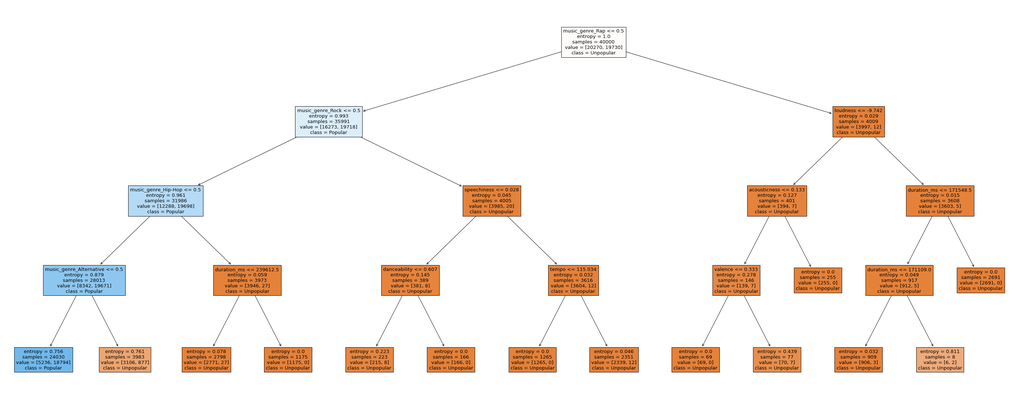

```python
fig, ax = plt.subplots(figsize=(50,20))
tree.plot_tree(treeclf3, feature_names=mc_train.columns, class_names=['Unpopular','Popular'], filled=True, ax=ax);
```

```python
dot_data = export_graphviz(treeclf3,out_file=None, feature_names=mc_train.columns,
                           class_names=['Unpopular','Popular'], filled=True, rotate=True)
graph = graphviz.Source(dot_data)
graph
```

[figure not shown]

```python
#tree = export_graphviz(treeclf3, out_file=None, feature_names=mc_train.columns, class_names=['Unpopular','Popular'])
#graph = Source(tree)
#display(SVG(graph.pipe(format='svg')))
```

```python
print("Accuracy on Training: %0.4f" % treeclf3.score(mc_train, mc_target_train))
print("Overall Accuracy on X-Val: %0.4f (+/- %0.4f)" % (cv_scores.mean(), cv_scores.std() * 2))
print("Accuracy on Test: %0.4f" % treeclf4.score(mc_test, mc_target_test))
```

[output not shown]

```python
treeclf3.feature_importances_
```

```
array([0.  , 0.  , 0.  , 0.  , 0.  , 0.  , 0.  , 0.  , 0.  , 0.  , 0.19, 0.  , 0.  , 0.  , 0.  , 0.  , 0.32, 0.  ,
       0.22, 0.26, 0.  , 0.  , 0.  , 0.  , 0.  , 0.  , 0.  , 0.  , 0.  , 0.  , 0.  , 0.  , 0.  , 0.  , 0.  , 0.  ,
       0.  , 0.  , 0.  , 0.  , 0.  , 0.  , 0.  , 0.  ])
```

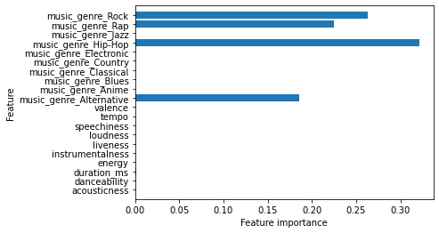

```python
def plot_feature_importances(model, n_features, feature_names):
    plt.barh(range(n_features), model.feature_importances_[:n_features], align='center')
    plt.yticks(np.arange(n_features), feature_names)
    plt.xlabel("Feature importance")
    plt.ylabel("Feature")
    plt.ylim(-1, n_features)

features = mc_train.columns[:20]
plot_feature_importances(treeclf3, 20, features)
```

### 4-3. Naive Bayes (Gaussian)

```python
from sklearn import naive_bayes
```

```python
nbclf = naive_bayes.GaussianNB()

print('[Naive Bayes (Gaussian)]')

nbclf = nbclf.fit(mc_train, mc_target_train)
print("Accuracy on Training: %0.4f" % nbclf.score(mc_train, mc_target_train))

nb_cv_scores = cross_val_score(nbclf, mc_train, mc_target_train, cv=10)
#print(nb_cv_scores)
print("Overall Accuracy: %0.4f (+/- %0.4f)" % (nb_cv_scores.mean(), nb_cv_scores.std() * 2))

nbpreds_test = nbclf.predict(mc_test)
print("Accuracy on Test: %0.4f" % nbclf.score(mc_test, mc_target_test))
```

```
[Naive Bayes (Gaussian)]
Accuracy on Training: 0.6028
Overall Accuracy: 0.6028 (+/- 0.0169)
Accuracy on Test: 0.6118
```

### 4-4. Linear discriminant analysis (LDA)

```python
from sklearn.discriminant_analysis import LinearDiscriminantAnalysis
```

```python
ldclf = LinearDiscriminantAnalysis()

print('[Linear discriminant analysis (LDA)]')

ldclf = ldclf.fit(mc_train, mc_target_train)
print("Accuracy on Training: %0.4f" % ldclf.score(mc_train, mc_target_train))

ld_cv_scores = cross_val_score(ldclf, mc_train, mc_target_train, cv=10)
#print(ld_cv_scores)
print("Overall Accuracy: %0.4f (+/- %0.4f)" % (ld_cv_scores.mean(), ld_cv_scores.std() * 2))

ldpreds_test = ldclf.predict(mc_test)
print("Accuracy on Test: %0.4f" % ldclf.score(mc_test, mc_target_test))
```

```
[Linear discriminant analysis (LDA)]
Accuracy on Training: 0.8469
Overall Accuracy: 0.8449 (+/- 0.0127)
Accuracy on Test: 0.8430
```

### 4-5. Random Forest

#### A versatile function to measure performance of a model

```python
from sklearn import metrics

def measure_performance(X, y, clf, show_accuracy=True, show_classification_report=True, show_confussion_matrix=True):
    y_pred = clf.predict(X)
    if show_accuracy:
         print("Accuracy on Test:{0:.4f}".format(metrics.accuracy_score(y, y_pred)),"\n")
    if show_classification_report:
        print("Classification report")
        print(metrics.classification_report(y, y_pred),"\n")

    if show_confussion_matrix:
        print("Confussion matrix")
        print(metrics.confusion_matrix(y, y_pred),"\n")
```

```python
from sklearn.ensemble import RandomForestClassifier
```

```python
rf = RandomForestClassifier(n_estimators=10, random_state=33)
rf = rf.fit(mc_train, mc_target_train)
print("Accuracy on Training: %0.4f" % rf.score(mc_train, mc_target_train))
measure_performance(mc_test, mc_target_test, rf, show_confussion_matrix=False, show_classification_report=False)
```

```
Accuracy on Training: 0.9924
Accuracy on Test:0.8307
```

#### Exploring and comparing model parameters¶

#### Let's use the "calc_params" function to explore the impact of individual parameters using cross-validation.

```python
from sklearn.model_selection import KFold

def calc_params(X, y, clf, param_values, param_name, K):

    # Convert input to Numpy arrays
    X = np.array(X)
    y = np.array(y)

    # initialize training and testing score arrays with zeros
    train_scores = np.zeros(len(param_values))
    test_scores = np.zeros(len(param_values))

    # iterate over the different parameter values
    for i, param_value in enumerate(param_values):

        # set classifier parameters
        clf.set_params(**{param_name:param_value})

        # initialize the K scores obtained for each fold
        k_train_scores = np.zeros(K)
        k_test_scores = np.zeros(K)

        # create KFold cross validation
        cv = KFold(n_splits=K, shuffle=True, random_state=0)

        # iterate over the K folds
        j = 0
        for train, test in cv.split(X):
            # fit the classifier in the corresponding fold
            # and obtain the corresponding accuracy scores on train and test sets
            clf.fit(X[train], y[train])
            k_train_scores[j] = clf.score(X[train], y[train])
            k_test_scores[j] = clf.score(X[test], y[test])
            j += 1

        # store the mean of the K fold scores
        train_scores[i] = np.mean(k_train_scores)
        test_scores[i] = np.mean(k_test_scores)
        diff = abs(train_scores[i] - test_scores[i])
        print(param_name, '=', param_value, "Train =", train_scores[i], "Test =", test_scores[i], "Diff =", diff)

    # plot the training and testing scores in a log scale
    plt.plot(param_values, train_scores, label='Train', alpha=0.4, lw=2, c='b')
    plt.plot(param_values, test_scores, label='X-Val', alpha=0.4, lw=2, c='g')
    plt.legend(loc=7)
    plt.xlabel(param_name + " values")
    plt.ylabel("Mean cross validation accuracy")

    # return the training and testing scores on each parameter value
    return train_scores, test_scores
```

#### Explore 'min_samples_leaf'

```
min_samples_leaf = 1 Train = 0.9921 Test = 0.8337749999999999 Diff = 0.15832500000000005
min_samples_leaf = 2 Train = 0.9562375 Test = 0.84005 Diff = 0.1161875
min_samples_leaf = 3 Train = 0.929025 Test = 0.8428000000000001 Diff = 0.08622499999999989
min_samples_leaf = 4 Train = 0.9117312500000001 Test = 0.8432999999999999 Diff = 0.06843125000000017
min_samples_leaf = 5 Train = 0.9007312500000001 Test = 0.8452 Diff = 0.05553125000000014
min_samples_leaf = 6 Train = 0.89384375 Test = 0.8452999999999999 Diff = 0.04854375000000011
min_samples_leaf = 7 Train = 0.8881062500000001 Test = 0.8459499999999999 Diff = 0.04215625000000023
min_samples_leaf = 8 Train = 0.8839749999999998 Test = 0.8450000000000001 Diff = 0.03897499999999976
min_samples_leaf = 9 Train = 0.88043125 Test = 0.8459249999999999 Diff = 0.03450625000000007
min_samples_leaf = 10 Train = 0.8772437499999999 Test = 0.8452500000000001 Diff = 0.03199374999999982
```

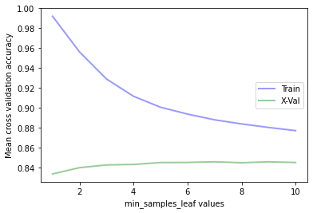

```python
msl = range(1,11)
rf = RandomForestClassifier(n_estimators=10, random_state=33)
train_scores, test_scores = calc_params(mc_train, mc_target_train, rf, msl, 'min_samples_leaf', 5)
```

#### Explore 'max_depth'

```
max_depth = 1 Train = 0.7260625 Test = 0.725325 Diff = 0.0007375000000000576
max_depth = 2 Train = 0.743375 Test = 0.7422250000000001 Diff = 0.0011499999999998733
max_depth = 3 Train = 0.8127625 Test = 0.8121 Diff = 0.0006625000000000103
max_depth = 4 Train = 0.8314625 Test = 0.8314 Diff = 6.249999999996536e-05
max_depth = 5 Train = 0.833475 Test = 0.8324 Diff = 0.0010749999999999371
max_depth = 6 Train = 0.8386374999999999 Test = 0.8368749999999998 Diff = 0.0017625000000001112
max_depth = 7 Train = 0.8423187500000001 Test = 0.83965 Diff = 0.0026687500000001085
max_depth = 8 Train = 0.84469375 Test = 0.84055 Diff = 0.004143750000000002
max_depth = 9 Train = 0.8474562499999999 Test = 0.8420500000000001 Diff = 0.005406249999999835
max_depth = 10 Train = 0.8517062500000001 Test = 0.84385 Diff = 0.00785625000000012
max_depth = 11 Train = 0.85599375 Test = 0.8425250000000002 Diff = 0.013468749999999807
max_depth = 12 Train = 0.8614875 Test = 0.845125 Diff = 0.016362499999999947
max_depth = 13 Train = 0.86558125 Test = 0.8448 Diff = 0.020781249999999973
max_depth = 14 Train = 0.8728187500000001 Test = 0.8447250000000001 Diff = 0.02809375000000003
max_depth = 15 Train = 0.88325625 Test = 0.8453250000000001 Diff = 0.03793124999999986
max_depth = 16 Train = 0.89368125 Test = 0.84435 Diff = 0.04933124999999994
max_depth = 17 Train = 0.9024125 Test = 0.8436499999999999 Diff = 0.05876250000000005
max_depth = 18 Train = 0.91603125 Test = 0.842075 Diff = 0.07395624999999995
max_depth = 19 Train = 0.9249625 Test = 0.8426500000000001 Diff = 0.0823124999999999
max_depth = 20 Train = 0.937425 Test = 0.8413499999999999 Diff = 0.09607500000000002
```

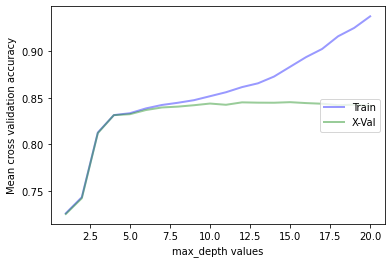

```python
m_depth = range(1,21)

rf = RandomForestClassifier(n_estimators=10, random_state=33)
train_scores, test_scores = calc_params(mc_train, mc_target_train, rf, m_depth, 'max_depth', 5)
```

#### Explore 'n_estimators'

```
n_estimators = 5 Train = 0.97835625 Test = 0.824675 Diff = 0.15368125
n_estimators = 10 Train = 0.9921 Test = 0.8337749999999999 Diff = 0.15832500000000005
n_estimators = 15 Train = 0.99535625 Test = 0.840925 Diff = 0.15443125000000002
n_estimators = 20 Train = 0.9976375 Test = 0.8417749999999999 Diff = 0.15586250000000001
n_estimators = 25 Train = 0.9981562500000001 Test = 0.843525 Diff = 0.1546312500000001
n_estimators = 30 Train = 0.9989874999999999 Test = 0.844425 Diff = 0.15456249999999994
n_estimators = 35 Train = 0.9991312499999999 Test = 0.8461749999999999 Diff = 0.15295625000000002
n_estimators = 40 Train = 0.99948125 Test = 0.8447749999999999 Diff = 0.15470625000000005
n_estimators = 45 Train = 0.99951875 Test = 0.8464750000000001 Diff = 0.15304374999999992
n_estimators = 50 Train = 0.999625 Test = 0.845875 Diff = 0.15374999999999994
n_estimators = 55 Train = 0.9996937499999999 Test = 0.8461749999999999 Diff = 0.15351875000000004
n_estimators = 60 Train = 0.99973125 Test = 0.8458500000000001 Diff = 0.15388124999999986
n_estimators = 65 Train = 0.99976875 Test = 0.8462999999999999 Diff = 0.15346875000000004
n_estimators = 70 Train = 0.9997875 Test = 0.8456249999999998 Diff = 0.1541625000000002
n_estimators = 75 Train = 0.9997812499999998 Test = 0.8460000000000001 Diff = 0.15378124999999976
n_estimators = 80 Train = 0.9998250000000001 Test = 0.84615 Diff = 0.15367500000000012
n_estimators = 85 Train = 0.9998374999999999 Test = 0.8464 Diff = 0.1534374999999999
n_estimators = 90 Train = 0.99985 Test = 0.846125 Diff = 0.153725
n_estimators = 95 Train = 0.99985625 Test = 0.8460750000000001 Diff = 0.15378124999999987
n_estimators = 100 Train = 0.99985625 Test = 0.845575 Diff = 0.15428125000000004
```

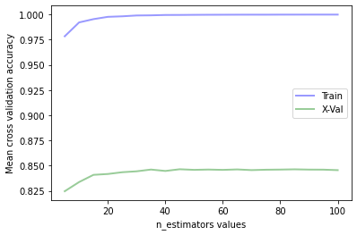

```python
nest = range(5, 101, 5)
rf = RandomForestClassifier(n_estimators=10, random_state=33)
train_scores, test_scores = calc_params(mc_train, mc_target_train, rf, nest, 'n_estimators', 5)
```

#### Not a bif difference, butn_estimators= 35 works well in this case.

#### Final model with these parameters

```python
rf = RandomForestClassifier(n_estimators=35, min_samples_leaf=9, max_depth=3, random_state=33)

print('[Random Forest]')
rf = rf.fit(mc_train, mc_target_train)
print("Accuracy on Training: %0.4f" % rf.score(mc_train, mc_target_train))

measure_performance(mc_test, mc_target_test, rf, show_confussion_matrix=False, show_classification_report=False)
```

```
[Random Forest]
Accuracy on Training: 0.8294
Accuracy on Test:0.8305
```

```python
rf.feature_importances_
```

```
array([0.04, 0.04, 0.  , 0.04, 0.11, 0.  , 0.05, 0.04, 0.  , 0.01, 0.03, 0.13, 0.04, 0.05, 0.  , 0.02, 0.1 , 0.01,
       0.19, 0.1 , 0.  , 0.  , 0.  , 0.  , 0.  , 0.  , 0.  , 0.  , 0.  , 0.  , 0.  , 0.  , 0.  , 0.  , 0.  , 0.  ,
       0.  , 0.  , 0.  , 0.  , 0.  , 0.  , 0.  , 0.  ])
```

```python
mc_train.columns
```

```
Index(['acousticness', 'danceability', 'duration_ms', 'energy',
       'instrumentalness', 'liveness', 'loudness', 'speechiness', 'tempo',
       'valence', 'music_genre_Alternative', 'music_genre_Anime',
       'music_genre_Blues', 'music_genre_Classical', 'music_genre_Country',
       'music_genre_Electronic', 'music_genre_Hip-Hop', 'music_genre_Jazz',
       'music_genre_Rap', 'music_genre_Rock', 'keyMode_A Major',
       'keyMode_A Minor', 'keyMode_A# Major', 'keyMode_A# Minor',
       'keyMode_B Major', 'keyMode_B Minor', 'keyMode_C Major',
       'keyMode_C Minor', 'keyMode_C# Major', 'keyMode_C# Minor',
       'keyMode_D Major', 'keyMode_D Minor', 'keyMode_D# Major',
       'keyMode_D# Minor', 'keyMode_E Major', 'keyMode_E Minor',
       'keyMode_F Major', 'keyMode_F Minor', 'keyMode_F# Major',
       'keyMode_F# Minor', 'keyMode_G Major', 'keyMode_G Minor',
       'keyMode_G# Major', 'keyMode_G# Minor'],
      dtype='object')
```

```python
for i in range(len(mc_train.columns)):
    a = mc_train.columns[i]
    b = rf.feature_importances_[i]
    print(a, '% 0.2f' %b)
```

[output not shown]

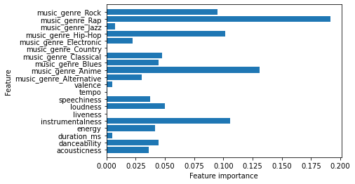

```python
def plot_feature_importances(model, n_features, feature_names):
    plt.barh(range(n_features), model.feature_importances_[:n_features], align='center')
    plt.yticks(np.arange(n_features), feature_names)
    plt.xlabel("Feature importance")
    plt.ylabel("Feature")
    plt.ylim(-1, n_features)

features = mc_train.columns[:20]
plot_feature_importances(rf, 20, features)
```

```python
import graphviz
from sklearn.tree import export_graphviz

dot_data = export_graphviz(rf.estimators_[0],out_file=None, feature_names=mc_train.columns,
                           class_names=['Unpopular','Popular'], filled=True, rotate=True)
graph = graphviz.Source(dot_data)
graph
```

[figure not shown]

### 4-6. Ada Boost

```python
from sklearn.ensemble import AdaBoostClassifier
```

```python
ab = AdaBoostClassifier(random_state=33)
ab = ab.fit(mc_train, mc_target_train)

print("Accuracy on Training: %0.4f" % ab.score(mc_train, mc_target_train))
measure_performance(mc_test, mc_target_test, ab, show_confussion_matrix=False, show_classification_report=False)
```

```
Accuracy on Training: 0.8480
Accuracy on Test:0.8454
```

#### Let's use grid search to explore the parameter space more systematically.

```python
from sklearn.model_selection import GridSearchCV
```

```python
ab = AdaBoostClassifier()
```

```python
parameters = {
    'learning_rate': [0.01, 0.05, 0.1, 0.2, 0.3, 0.4, 0.6, 0.7, 0.8, 0.9, 1.0, 1.3, 1.5, 1.8, 2.0],
    'n_estimators': range(5, 101, 5),
}

gs = GridSearchCV(ab, parameters, cv=5)
```

```python
%time _ = gs.fit(mc_train, mc_target_train)
```

```
CPU times: total: 1h 27min 22s
Wall time: 1h 29min 31s
```

```python
gs.best_params_, gs.best_score_
```

```
({'learning_rate': 0.9, 'n_estimators': 75}, 0.847075)
```

#### Final AdaBoost model

```python
ab = AdaBoostClassifier(n_estimators=75, learning_rate=0.9, random_state=33)

print('[Ada Boost]')

ab = ab.fit(mc_train, mc_target_train)
print("Accuracy on Training: %0.4f" % ab.score(mc_train, mc_target_train))
measure_performance(mc_test, mc_target_test, ab, show_confussion_matrix=False, show_classification_report=False)
```

```
[Ada Boost]
Accuracy on Training: 0.8465
Accuracy on Test:0.8469
```

### 4-7. Gradient Boosted Decision Trees (GBDT)

```python
from sklearn.ensemble import GradientBoostingClassifier
```

```python
gb = GradientBoostingClassifier(n_estimators=45, learning_rate=1.0, max_depth=3, random_state=33)

print('[GBDT]')

gb = gb.fit(mc_train, mc_target_train)
print("Accuracy on Training: %0.4f" % gb.score(mc_train, mc_target_train))
print('Accuracy on Test: %0.4f' % gb.score(mc_test, mc_target_test))
```

```
[GBDT]
Accuracy on Training: 0.8561
Accuracy on Test: 0.8416
```

### 4-8. Bagging

```python
from sklearn.ensemble import BaggingClassifier
from sklearn.neighbors import KNeighborsClassifier
```

```python
bagging = BaggingClassifier(KNeighborsClassifier(), max_samples=0.5, max_features=0.5, n_estimators=25, random_state=33)

print('[Bagging]')

bagging.fit(mc_train, mc_target_train)
print("Accuracy on Training: %0.4f" % bagging.score(mc_train, mc_target_train))
print('Accuracy on Test: %0.4f' % bagging.score(mc_test, mc_target_test))
```

```
[Bagging]
Accuracy on Training: 0.8628
Accuracy on Test: 0.7814
```

### 5. Clustering

#### Normalize the dataset aftering creating dummy variables

```python
min_max_scaler = preprocessing.MinMaxScaler()
min_max_scaler.fit(mc_matrix)
mc_norm = min_max_scaler.fit_transform(mc_matrix)
mc_norm = pd.DataFrame(mc_norm)
mc_norm
```

|  | 0 | 1 | 2 | 3 | 4 | 5 | 6 | 7 | 8 | 9 | ... | 34 | 35 | 36 | 37 | 38 | 39 | 40 | 41 | 42 | 43 |
| --- | --- | --- | --- | --- | --- | --- | --- | --- | --- | --- | --- | --- | --- | --- | --- | --- | --- | --- | --- | --- | --- |
| 0 | 0.00 | 0.64 | 0.00 | 0.94 | 0.80 | 0.11 | 0.82 | 0.06 | 0.36 | 0.77 | ... | 0.00 | 0.00 | 0.00 | 0.00 | 0.00 | 0.00 | 0.00 | 0.00 | 0.00 | 0.00 |
| 1 | 0.01 | 0.61 | 0.05 | 0.89 | 0.95 | 0.12 | 0.79 | 0.01 | 0.43 | 0.54 | ... | 0.00 | 0.00 | 0.00 | 0.00 | 0.00 | 0.00 | 0.00 | 0.00 | 0.00 | 0.00 |
| 2 | 0.00 | 0.60 | 0.04 | 0.76 | 0.01 | 0.53 | 0.84 | 0.01 | 0.50 | 0.34 | ... | 0.00 | 0.00 | 0.00 | 0.00 | 0.00 | 0.00 | 0.00 | 0.00 | 1.00 | 0.00 |
| 3 | 0.03 | 0.77 | 0.03 | 0.70 | 0.00 | 0.15 | 0.84 | 0.24 | 0.50 | 0.27 | ... | 0.00 | 0.00 | 0.00 | 0.00 | 0.00 | 0.00 | 0.00 | 0.00 | 0.00 | 0.00 |
| 4 | 0.00 | 0.62 | 0.05 | 0.59 | 0.91 | 0.15 | 0.80 | 0.02 | 0.60 | 0.33 | ... | 0.00 | 0.00 | 0.00 | 0.00 | 1.00 | 0.00 | 0.00 | 0.00 | 0.00 | 0.00 |
| ... | ... | ... | ... | ... | ... | ... | ... | ... | ... | ... | ... | ... | ... | ... | ... | ... | ... | ... | ... | ... | ... |
| 49995 | 0.03 | 0.92 | 0.00 | 0.57 | 0.00 | 0.11 | 0.79 | 0.30 | 0.34 | 0.33 | ... | 0.00 | 0.00 | 0.00 | 0.00 | 0.00 | 0.00 | 0.00 | 0.00 | 0.00 | 0.00 |
| 49996 | 0.16 | 0.70 | 0.05 | 0.36 | 0.00 | 0.10 | 0.73 | 0.04 | 0.47 | 0.11 | ... | 0.00 | 0.00 | 0.00 | 0.00 | 0.00 | 0.00 | 0.00 | 0.00 | 0.00 | 0.00 |
| 49997 | 0.01 | 0.68 | 0.04 | 0.76 | 0.00 | 0.13 | 0.82 | 0.13 | 0.52 | 0.40 | ... | 0.00 | 0.00 | 0.00 | 0.00 | 0.00 | 0.00 | 0.00 | 0.00 | 0.00 | 0.00 |
| 49998 | 0.08 | 0.78 | 0.05 | 0.47 | 0.00 | 0.10 | 0.83 | 0.02 | 0.22 | 0.36 | ... | 0.00 | 0.00 | 0.00 | 0.00 | 0.00 | 0.00 | 0.00 | 1.00 | 0.00 | 0.00 |
| 49999 | 0.10 | 0.87 | 0.06 | 0.64 | 0.00 | 0.26 | 0.66 | 0.09 | 0.35 | 0.77 | ... | 0.00 | 0.00 | 0.00 | 0.00 | 0.00 | 1.00 | 0.00 | 0.00 | 0.00 | 0.00 |

50000 rows × 44 columns

```python
from sklearn.cluster import KMeans
```

```python
kmeans = KMeans(n_clusters=2, max_iter=500, verbose=1) # initialization
kmeans.fit(mc_norm)
```

[output not shown]

[output cut: 97 more lines]

[output not shown]

```
KMeans(max_iter=500, n_clusters=2, verbose=1)
```

```python
clusters = kmeans.predict(mc_norm)
pd.DataFrame(clusters, columns=["Cluster"])
```

|  | Cluster |
| --- | --- |
| 0 | 1 |
| 1 | 1 |
| 2 | 1 |
| 3 | 1 |
| 4 | 1 |
| ... | ... |
| 49995 | 1 |
| 49996 | 1 |
| 49997 | 1 |
| 49998 | 1 |
| 49999 | 1 |

50000 rows × 1 columns

```python
pd.options.display.float_format='{:,.2f}'.format

centroids = pd.DataFrame(kmeans.cluster_centers_)
centroids
```

|  | 0 | 1 | 2 | 3 | 4 | 5 | 6 | 7 | 8 | 9 | ... | 34 | 35 | 36 | 37 | 38 | 39 | 40 | 41 | 42 | 43 |
| --- | --- | --- | --- | --- | --- | --- | --- | --- | --- | --- | --- | --- | --- | --- | --- | --- | --- | --- | --- | --- | --- |
| 0 | 0.87 | 0.34 | 0.05 | 0.19 | 0.60 | 0.15 | 0.55 | 0.03 | 0.39 | 0.25 | ... | 0.03 | 0.05 | 0.07 | 0.04 | 0.02 | 0.02 | 0.08 | 0.04 | 0.05 | 0.01 |
| 1 | 0.19 | 0.58 | 0.04 | 0.69 | 0.09 | 0.19 | 0.79 | 0.09 | 0.47 | 0.50 | ... | 0.03 | 0.04 | 0.04 | 0.04 | 0.03 | 0.03 | 0.09 | 0.02 | 0.05 | 0.02 |

2 rows × 44 columns

#### Evaluate the clusters with Silhouette analysis, the Completeness values, and Homogeneity values.

```python
from sklearn import metrics
```

```python
silhouettes = metrics.silhouette_samples(mc_norm, clusters)
print(silhouettes[:20])
print('\nMean Silhouette Value: %0.4f' %silhouettes.mean())
```

```
[ 0.12283959  0.08540289  0.16624704  0.17274645  0.06778711  0.09106752
  0.16389314  0.08881431  0.1727723   0.15196681 -0.01322978  0.10476016
  0.16722839  0.03694366  0.11393675  0.14653786  0.13316126  0.16072207
  0.13630621  0.06495673]

Mean Silhouette Value: 0.1374
```

```python
def plot_silhouettes(data, clusters, metric='euclidean'):

    from matplotlib import cm
    from sklearn.metrics import silhouette_samples

    cluster_labels = np.unique(clusters)
    n_clusters = cluster_labels.shape[0]
    silhouette_vals = metrics.silhouette_samples(data, clusters, metric='euclidean')
    c_ax_lower, c_ax_upper = 0, 0
    cticks = []
    for i, k in enumerate(cluster_labels):
        c_silhouette_vals = silhouette_vals[clusters == k]
        c_silhouette_vals.sort()
        c_ax_upper += len(c_silhouette_vals)
        color = cm.jet(float(i) / n_clusters)
        pl.barh(range(c_ax_lower, c_ax_upper), c_silhouette_vals, height=1.0,
                      edgecolor='none', color=color)

        cticks.append((c_ax_lower + c_ax_upper) / 2)
        c_ax_lower += len(c_silhouette_vals)

    silhouette_avg = np.mean(silhouette_vals)
    pl.axvline(silhouette_avg, color="red", linestyle="--")

    pl.yticks(cticks, cluster_labels)
    pl.ylabel('Cluster')
    pl.xlabel('Silhouette coefficient')

    pl.tight_layout()
    #pl.savefig('images/11_04.png', dpi=300)
    pl.show()

    return
```

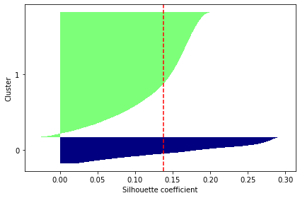

```python
plot_silhouettes(mc_norm, clusters)
```

```python
from sklearn.metrics import completeness_score, homogeneity_score
```

```python
# Completeness: all members of a given class are assigned to the same cluster.
# Homogeneity: each cluster contains only members of a single class.
print('Completeness without PCA: %0.4f' %completeness_score(mc_target, clusters))
print ('Homogeneity without PCA: %0.4f' %homogeneity_score(mc_target, clusters))
```

```
Completeness without PCA: 0.1205
Homogeneity without PCA: 0.0805
```

#### The performance of clustering is not very good, so we can try to use PCA to reduce the dimensionality of the data, and then do clustering with the dataset after PCA.

```python
from sklearn import decomposition
```

```python
pca = decomposition.PCA()
mc_norm_trans = pca.fit(mc_norm).transform(mc_norm)

# Here is teh transformed feature space based on the PCs
np.set_printoptions(precision=2,suppress=True, edgeitems=5, linewidth=120)
print(mc_norm_trans)
```

```
[[-0.2   1.03 -0.06  0.27  0.42 ... -0.03 -0.01 -0.05 -0.    0.  ]
 [-0.02  1.1  -0.14  0.2   0.43 ... -0.03  0.01 -0.01 -0.    0.  ]
 [-0.37  0.68 -0.    0.01  0.41 ... -0.1  -0.02 -0.01 -0.    0.  ]
 [-0.38  0.77  0.29 -0.05  0.47 ...  0.13 -0.03 -0.01  0.    0.  ]
 [ 0.08  1.05 -0.08  0.12  0.47 ... -0.04 -0.08 -0.01 -0.    0.  ]
 ...
 [-0.41  0.02  0.91 -0.14  0.02 ...  0.09 -0.   -0.04  0.    0.  ]
 [-0.13 -0.11  0.63 -0.18 -0.   ... -0.14 -0.    0.01  0.   -0.  ]
 [-0.46 -0.09  0.45 -0.17  0.02 ... -0.07  0.02 -0.   -0.   -0.  ]
 [-0.25 -0.09  0.63 -0.07 -0.03 ... -0.14 -0.07  0.01 -0.    0.  ]
 [-0.43 -0.13  0.61  0.04 -0.04 ... -0.12  0.12  0.02 -0.   -0.  ]]
```

```python
varPercentage = pca.explained_variance_ratio_*100
print(varPercentage)
```

```
[12.71  5.48  5.03  4.67  4.37  4.34  4.33  4.32  4.31  3.71  3.6   3.24  2.97  2.41  2.31  2.13  2.06  1.92  1.82
  1.79  1.72  1.66  1.56  1.46  1.44  1.41  1.37  1.29  1.28  1.21  1.16  1.07  1.01  1.    0.89  0.73  0.69  0.54
  0.49  0.34  0.11  0.03  0.    0.  ]
```

```python
acc = 0
pcs = 0
for i in varPercentage:
    acc += i
    pcs += 1
    if acc >=95 and acc<=96:
        print('Variance percentage for PCs', pcs, 'is:', '{0:.3f}'.format(acc))
```

```
Variance percentage for PCs 33 is: 95.169
```

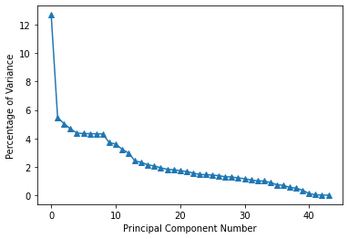

```python
import matplotlib
import matplotlib.pyplot as plt

fig = plt.figure()
ax = fig.add_subplot(111)
ax.plot(range(44), varPercentage[:], marker='^')
plt.xlabel('Principal Component Number')
plt.ylabel('Percentage of Variance')
plt.show()
```

#### Note that the first 33 PCs cumulatively explain about 95% of variance in the data. So, we will use only the first 33 PCs as the dimensions for our reduced feature space.

```python
mc_norm_trans_reduced = mc_norm_trans[:,:33]
print(mc_norm_trans_reduced.shape)
pd.DataFrame(mc_norm_trans_reduced)
```

```
(50000, 33)
```

|  | 0 | 1 | 2 | 3 | 4 | 5 | 6 | 7 | 8 | 9 | ... | 23 | 24 | 25 | 26 | 27 | 28 | 29 | 30 | 31 | 32 |
| --- | --- | --- | --- | --- | --- | --- | --- | --- | --- | --- | --- | --- | --- | --- | --- | --- | --- | --- | --- | --- | --- |
| 0 | -0.20 | 1.03 | -0.06 | 0.27 | 0.42 | 0.24 | 0.13 | 0.12 | -0.00 | 0.02 | ... | -0.45 | -0.50 | -0.11 | -0.08 | 0.02 | -0.01 | -0.04 | -0.04 | -0.03 | -0.01 |
| 1 | -0.02 | 1.10 | -0.14 | 0.20 | 0.43 | 0.23 | 0.12 | 0.12 | -0.00 | 0.03 | ... | 0.08 | 0.07 | 0.04 | 0.04 | 0.02 | 0.00 | 0.02 | -0.02 | 0.23 | 0.95 |
| 2 | -0.37 | 0.68 | -0.00 | 0.01 | 0.41 | 0.21 | 0.10 | 0.12 | 0.01 | 0.05 | ... | -0.04 | 0.03 | -0.04 | -0.01 | -0.06 | -0.02 | -0.01 | 0.21 | -0.05 | 0.02 |
| 3 | -0.38 | 0.77 | 0.29 | -0.05 | 0.47 | 0.24 | 0.09 | 0.09 | -0.02 | 0.04 | ... | -0.02 | 0.01 | -0.00 | -0.02 | 0.01 | -0.01 | -0.03 | -0.13 | -0.02 | -0.01 |
| 4 | 0.08 | 1.05 | -0.08 | 0.12 | 0.47 | 0.21 | 0.13 | 0.12 | -0.01 | 0.04 | ... | 0.29 | -0.01 | 0.74 | -0.46 | -0.24 | -0.10 | -0.10 | 0.02 | -0.04 | -0.07 |
| ... | ... | ... | ... | ... | ... | ... | ... | ... | ... | ... | ... | ... | ... | ... | ... | ... | ... | ... | ... | ... | ... |
| 49995 | -0.41 | 0.02 | 0.91 | -0.14 | 0.02 | 0.16 | -0.15 | -0.27 | -0.63 | -0.04 | ... | 0.00 | 0.02 | 0.01 | -0.00 | -0.02 | -0.01 | -0.01 | -0.15 | -0.05 | 0.04 |
| 49996 | -0.13 | -0.11 | 0.63 | -0.18 | -0.00 | 0.13 | -0.11 | -0.24 | -0.61 | -0.02 | ... | 0.68 | -0.06 | -0.57 | -0.21 | -0.15 | -0.07 | -0.09 | -0.20 | -0.08 | -0.04 |
| 49997 | -0.46 | -0.09 | 0.45 | -0.17 | 0.02 | 0.21 | -0.11 | -0.29 | -0.59 | -0.02 | ... | 0.01 | 0.06 | 0.01 | 0.02 | -0.06 | -0.02 | 0.00 | -0.07 | 0.01 | -0.01 |
| 49998 | -0.25 | -0.09 | 0.63 | -0.07 | -0.03 | 0.14 | -0.11 | -0.24 | -0.61 | -0.03 | ... | 0.11 | 0.09 | 0.08 | 0.03 | 0.10 | 0.06 | 0.95 | -0.24 | -0.18 | 0.02 |
| 49999 | -0.43 | -0.13 | 0.61 | 0.04 | -0.04 | 0.16 | -0.12 | -0.25 | -0.62 | -0.03 | ... | 0.15 | 0.17 | 0.11 | 0.15 | 0.22 | 0.86 | -0.17 | 0.07 | -0.13 | -0.01 |

50000 rows × 33 columns

```python
kmeans = KMeans(n_clusters=2, max_iter=500, verbose=1) # initialization
kmeans.fit(mc_norm_trans_reduced)
```

[output not shown]

[output cut: 119 more lines]

[output not shown]

```
KMeans(max_iter=500, n_clusters=2, verbose=1)
```

```python
clusters_pca = kmeans.predict(mc_norm_trans_reduced)
pd.DataFrame(clusters_pca, columns=["Cluster"])
```

|  | Cluster |
| --- | --- |
| 0 | 1 |
| 1 | 1 |
| 2 | 1 |
| 3 | 1 |
| 4 | 1 |
| ... | ... |
| 49995 | 1 |
| 49996 | 1 |
| 49997 | 1 |
| 49998 | 1 |
| 49999 | 1 |

50000 rows × 1 columns

```python
silhouettes_pca = metrics.silhouette_samples(mc_norm_trans_reduced, clusters_pca)
print(silhouettes_pca[:20])
print('\nMean Silhouette Value with PCA: %0.4f' %silhouettes_pca.mean())
```

```
[ 0.12  0.09  0.17  0.18  0.07  0.09  0.17  0.09  0.18  0.15 -0.02  0.11  0.17  0.04  0.11  0.15  0.13  0.16  0.14
  0.06]

Mean Silhouette Value with PCA: 0.1420
```

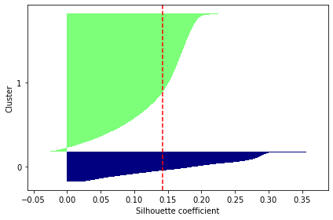

```python
plot_silhouettes(mc_norm_trans_reduced, clusters_pca)
```

```python
# Completeness: all members of a given class are assigned to the same cluster.
# Homogeneity: each cluster contains only members of a single class.
print('Completeness with PCA: %0.4f' %completeness_score(mc_target, clusters_pca))
print ('Homogeneity with PCA: %0.4f' %homogeneity_score(mc_target, clusters_pca))
```

```
Completeness with PCA: 0.1200
Homogeneity with PCA: 0.0812
```

```python
print('[kmeans without PCA]')
print('Mean Silhouette Value: %0.4f' %silhouettes.mean())
print('Completeness without PCA: %0.4f' %completeness_score(mc_target, clusters))
print ('Homogeneity without PCA: %0.4f' %homogeneity_score(mc_target, clusters))
print('-'*60)
print('[kmenas with PCA]')
print('Mean Silhouette Value with PCA: %0.4f' %silhouettes_pca.mean())
print('Completeness with PCA: %0.4f' %completeness_score(mc_target, clusters_pca))
print ('Homogeneity with PCA: %0.4f' %homogeneity_score(mc_target, clusters_pca))
```

```
[kmeans without PCA]
Mean Silhouette Value: 0.1374
Completeness without PCA: 0.1205
Homogeneity without PCA: 0.0805
------------------------------------------------------------
[kmenas with PCA]
Mean Silhouette Value with PCA: 0.1420
Completeness with PCA: 0.1200
Homogeneity with PCA: 0.0812
```

### 6. Regression Analysis

```python
mr = pd.get_dummies(music)
print(mr.shape)
mr.head()
```

```
(50000, 45)
```

|  | popularity | acousticness | danceability | duration_ms | energy | instrumentalness | liveness | loudness | speechiness | tempo | ... | keyMode_E Major | keyMode_E Minor | keyMode_F Major | keyMode_F Minor | keyMode_F# Major | keyMode_F# Minor | keyMode_G Major | keyMode_G Minor | keyMode_G# Major | keyMode_G# Minor |
| --- | --- | --- | --- | --- | --- | --- | --- | --- | --- | --- | --- | --- | --- | --- | --- | --- | --- | --- | --- | --- | --- |
| 0 | 27.00 | 0.00 | 0.65 | -1.00 | 0.94 | 0.79 | 0.12 | -5.20 | 0.07 | 100.89 | ... | 0 | 0 | 0 | 0 | 0 | 0 | 0 | 0 | 0 | 0 |
| 1 | 31.00 | 0.01 | 0.62 | 218,293.00 | 0.89 | 0.95 | 0.12 | -7.04 | 0.03 | 115.00 | ... | 0 | 0 | 0 | 0 | 0 | 0 | 0 | 0 | 0 | 0 |
| 2 | 28.00 | 0.00 | 0.62 | 215,613.00 | 0.76 | 0.01 | 0.53 | -4.62 | 0.03 | 127.99 | ... | 0 | 0 | 0 | 0 | 0 | 0 | 0 | 0 | 1 | 0 |
| 3 | 34.00 | 0.03 | 0.77 | 166,875.00 | 0.70 | 0.00 | 0.16 | -4.50 | 0.24 | 128.01 | ... | 0 | 0 | 0 | 0 | 0 | 0 | 0 | 0 | 0 | 0 |
| 4 | 32.00 | 0.00 | 0.64 | 222,369.00 | 0.59 | 0.91 | 0.16 | -6.27 | 0.04 | 145.04 | ... | 0 | 0 | 0 | 0 | 1 | 0 | 0 | 0 | 0 | 0 |

5 rows × 45 columns

```python
min_max_scaler = preprocessing.MinMaxScaler().fit(mr)

mr_norm = min_max_scaler.transform(mr)
mr_norm = pd.DataFrame(mr_norm, columns=mr.columns, index=mr.index)
print(mr_norm.shape)
mr_norm.head()
```

```
(50000, 45)
```

|  | popularity | acousticness | danceability | duration_ms | energy | instrumentalness | liveness | loudness | speechiness | tempo | ... | keyMode_E Major | keyMode_E Minor | keyMode_F Major | keyMode_F Minor | keyMode_F# Major | keyMode_F# Minor | keyMode_G Major | keyMode_G Minor | keyMode_G# Major | keyMode_G# Minor |
| --- | --- | --- | --- | --- | --- | --- | --- | --- | --- | --- | --- | --- | --- | --- | --- | --- | --- | --- | --- | --- | --- |
| 0 | 0.27 | 0.00 | 0.64 | 0.00 | 0.94 | 0.80 | 0.11 | 0.82 | 0.06 | 0.36 | ... | 0.00 | 0.00 | 0.00 | 0.00 | 0.00 | 0.00 | 0.00 | 0.00 | 0.00 | 0.00 |
| 1 | 0.31 | 0.01 | 0.61 | 0.05 | 0.89 | 0.95 | 0.12 | 0.79 | 0.01 | 0.43 | ... | 0.00 | 0.00 | 0.00 | 0.00 | 0.00 | 0.00 | 0.00 | 0.00 | 0.00 | 0.00 |
| 2 | 0.28 | 0.00 | 0.60 | 0.04 | 0.76 | 0.01 | 0.53 | 0.84 | 0.01 | 0.50 | ... | 0.00 | 0.00 | 0.00 | 0.00 | 0.00 | 0.00 | 0.00 | 0.00 | 1.00 | 0.00 |
| 3 | 0.34 | 0.03 | 0.77 | 0.03 | 0.70 | 0.00 | 0.15 | 0.84 | 0.24 | 0.50 | ... | 0.00 | 0.00 | 0.00 | 0.00 | 0.00 | 0.00 | 0.00 | 0.00 | 0.00 | 0.00 |
| 4 | 0.32 | 0.00 | 0.62 | 0.05 | 0.59 | 0.91 | 0.15 | 0.80 | 0.02 | 0.60 | ... | 0.00 | 0.00 | 0.00 | 0.00 | 1.00 | 0.00 | 0.00 | 0.00 | 0.00 | 0.00 |

5 rows × 45 columns

```python
mr_norm_names = mr_norm.columns.values
print(mr_norm_names)
```

```
['popularity' 'acousticness' 'danceability' 'duration_ms' 'energy' 'instrumentalness' 'liveness' 'loudness'
 'speechiness' 'tempo' 'valence' 'music_genre_Alternative' 'music_genre_Anime' 'music_genre_Blues'
 'music_genre_Classical' 'music_genre_Country' 'music_genre_Electronic' 'music_genre_Hip-Hop' 'music_genre_Jazz'
 'music_genre_Rap' 'music_genre_Rock' 'keyMode_A Major' 'keyMode_A Minor' 'keyMode_A# Major' 'keyMode_A# Minor'
 'keyMode_B Major' 'keyMode_B Minor' 'keyMode_C Major' 'keyMode_C Minor' 'keyMode_C# Major' 'keyMode_C# Minor'
 'keyMode_D Major' 'keyMode_D Minor' 'keyMode_D# Major' 'keyMode_D# Minor' 'keyMode_E Major' 'keyMode_E Minor'
 'keyMode_F Major' 'keyMode_F Minor' 'keyMode_F# Major' 'keyMode_F# Minor' 'keyMode_G Major' 'keyMode_G Minor'
 'keyMode_G# Major' 'keyMode_G# Minor']
```

```python
y = mr_norm['popularity']
X = mr_norm[mr_norm_names[1:]]
print(X.shape)
X.head()
```

```
(50000, 44)
```

|  | acousticness | danceability | duration_ms | energy | instrumentalness | liveness | loudness | speechiness | tempo | valence | ... | keyMode_E Major | keyMode_E Minor | keyMode_F Major | keyMode_F Minor | keyMode_F# Major | keyMode_F# Minor | keyMode_G Major | keyMode_G Minor | keyMode_G# Major | keyMode_G# Minor |
| --- | --- | --- | --- | --- | --- | --- | --- | --- | --- | --- | --- | --- | --- | --- | --- | --- | --- | --- | --- | --- | --- |
| 0 | 0.00 | 0.64 | 0.00 | 0.94 | 0.80 | 0.11 | 0.82 | 0.06 | 0.36 | 0.77 | ... | 0.00 | 0.00 | 0.00 | 0.00 | 0.00 | 0.00 | 0.00 | 0.00 | 0.00 | 0.00 |
| 1 | 0.01 | 0.61 | 0.05 | 0.89 | 0.95 | 0.12 | 0.79 | 0.01 | 0.43 | 0.54 | ... | 0.00 | 0.00 | 0.00 | 0.00 | 0.00 | 0.00 | 0.00 | 0.00 | 0.00 | 0.00 |
| 2 | 0.00 | 0.60 | 0.04 | 0.76 | 0.01 | 0.53 | 0.84 | 0.01 | 0.50 | 0.34 | ... | 0.00 | 0.00 | 0.00 | 0.00 | 0.00 | 0.00 | 0.00 | 0.00 | 1.00 | 0.00 |
| 3 | 0.03 | 0.77 | 0.03 | 0.70 | 0.00 | 0.15 | 0.84 | 0.24 | 0.50 | 0.27 | ... | 0.00 | 0.00 | 0.00 | 0.00 | 0.00 | 0.00 | 0.00 | 0.00 | 0.00 | 0.00 |
| 4 | 0.00 | 0.62 | 0.05 | 0.59 | 0.91 | 0.15 | 0.80 | 0.02 | 0.60 | 0.33 | ... | 0.00 | 0.00 | 0.00 | 0.00 | 1.00 | 0.00 | 0.00 | 0.00 | 0.00 | 0.00 |

5 rows × 44 columns

```python
# w/o target attribute "popularity"
feature_names = X.columns.values
print(feature_names)
```

```
['acousticness' 'danceability' 'duration_ms' 'energy' 'instrumentalness' 'liveness' 'loudness' 'speechiness' 'tempo'
 'valence' 'music_genre_Alternative' 'music_genre_Anime' 'music_genre_Blues' 'music_genre_Classical'
 'music_genre_Country' 'music_genre_Electronic' 'music_genre_Hip-Hop' 'music_genre_Jazz' 'music_genre_Rap'
 'music_genre_Rock' 'keyMode_A Major' 'keyMode_A Minor' 'keyMode_A# Major' 'keyMode_A# Minor' 'keyMode_B Major'
 'keyMode_B Minor' 'keyMode_C Major' 'keyMode_C Minor' 'keyMode_C# Major' 'keyMode_C# Minor' 'keyMode_D Major'
 'keyMode_D Minor' 'keyMode_D# Major' 'keyMode_D# Minor' 'keyMode_E Major' 'keyMode_E Minor' 'keyMode_F Major'
 'keyMode_F Minor' 'keyMode_F# Major' 'keyMode_F# Minor' 'keyMode_G Major' 'keyMode_G Minor' 'keyMode_G# Major'
 'keyMode_G# Minor']
```

```python
X_train, X_test, y_train, y_test = train_test_split(X, y, test_size=0.2, random_state=42)
X_train = np.array(X_train)
X_test = np.array(X_test)
y_train = np.array(y_train)
y_test = np.array(y_test)
```

```python
from sklearn.linear_model import LinearRegression
```

```python
linreg = LinearRegression()
linreg.fit(X_train, y_train)
```

```
LinearRegression()
```

```python
w = linreg.coef_
print(w)
```

```
[-3.21e-03  1.10e-02  6.29e-02  6.26e-04 -1.52e-02 -4.48e-02  6.34e-02 -4.83e-02 -4.61e-03 -5.29e-05  8.79e+10
  8.79e+10  8.79e+10  8.79e+10  8.79e+10  8.79e+10  8.79e+10  8.79e+10  8.79e+10  8.79e+10  1.44e+10  1.44e+10
  1.44e+10  1.44e+10  1.44e+10  1.44e+10  1.44e+10  1.44e+10  1.44e+10  1.44e+10  1.44e+10  1.44e+10  1.44e+10
  1.44e+10  1.44e+10  1.44e+10  1.44e+10  1.44e+10  1.44e+10  1.44e+10  1.44e+10  1.44e+10  1.44e+10  1.44e+10]
```

```python
# Let's put some names to the faces
for i in range(len(feature_names)):
    print("%25s   %2.2f" % (feature_names[i], linreg.coef_[i]))
```

```
             acousticness   -0.00
             danceability   0.01
              duration_ms   0.06
                   energy   0.00
         instrumentalness   -0.02
                 liveness   -0.04
                 loudness   0.06
              speechiness   -0.05
                    tempo   -0.00
                  valence   -0.00
  music_genre_Alternative   87854878360.01
        music_genre_Anime   87854878359.75
        music_genre_Blues   87854878359.86
    music_genre_Classical   87854878359.83
      music_genre_Country   87854878359.97
   music_genre_Electronic   87854878359.89
      music_genre_Hip-Hop   87854878360.10
         music_genre_Jazz   87854878359.92
          music_genre_Rap   87854878360.11
         music_genre_Rock   87854878360.10
          keyMode_A Major   14413844672.30
          keyMode_A Minor   14413844672.30
         keyMode_A# Major   14413844672.30
         keyMode_A# Minor   14413844672.31
          keyMode_B Major   14413844672.31
          keyMode_B Minor   14413844672.31
          keyMode_C Major   14413844672.30
          keyMode_C Minor   14413844672.31
         keyMode_C# Major   14413844672.31
         keyMode_C# Minor   14413844672.31
          keyMode_D Major   14413844672.30
          keyMode_D Minor   14413844672.31
         keyMode_D# Major   14413844672.30
         keyMode_D# Minor   14413844672.31
          keyMode_E Major   14413844672.30
          keyMode_E Minor   14413844672.31
          keyMode_F Major   14413844672.30
          keyMode_F Minor   14413844672.31
         keyMode_F# Major   14413844672.31
         keyMode_F# Minor   14413844672.30
          keyMode_G Major   14413844672.31
          keyMode_G Minor   14413844672.30
         keyMode_G# Major   14413844672.31
         keyMode_G# Minor   14413844672.31
```

#### Evaluate the accuracy of the regression model with MAE and RMSE.

```python
from sklearn.metrics import mean_squared_error, mean_absolute_error
```

```python
# the training dataset
p_train = linreg.predict(X_train)

rmse_train = np.sqrt(mean_squared_error(p_train, y_train))
print('RMSE on Training Data: %.4f' %rmse_train)

mae_train = mean_absolute_error(p_train, y_train)
print('MAE on Training Data: %.4f' %mae_train)
```

```
RMSE on Training Data: 0.0957
MAE on Training Data: 0.0721
```

```python
# the test dataset
p_test = linreg.predict(X_test)

rmse_test = np.sqrt(mean_squared_error(p_test, y_test))
print('RMSE on Test Data: %.4f' %rmse_test)

mae_test = mean_absolute_error(p_test, y_test)
print('MAE on Test Data: %.4f' %mae_test)
```

```
RMSE on Test Data: 0.0967
MAE on Test Data: 0.0722
```

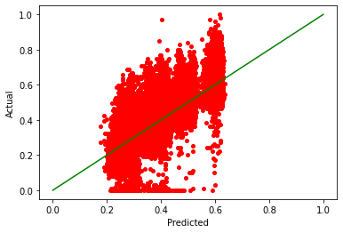

```python
# Plot predicted against actual (in the training data)
pl.plot(p_train, y_train, 'ro', markersize=4)
pl.plot([0,1], [0,1], 'g-')
pl.xlabel('Predicted')
pl.ylabel('Actual')
pl.show()
```

#### Typically, in the course of parameter optimization for the model, we compare the performance of the model on the training data (with a specific set of hyper-parameter values) to it's performance on cross-validation. The cross-validation is performed using partitions of the training data. Below is one approach to perform cross-validation using the KFold function in sklearn.model_selection.¶

```python
# perform 10-fold cross-validation on the training partition
def cross_validate(model, X, y, n, verbose=False):
    # model: regression model to be trained
    # X: the training data matrix
    # y: the training target variable array
    # n: the number of fold for x-validation
    # Returns mean RMSE across all folds

    from sklearn.metrics import mean_squared_error

    from sklearn.model_selection import KFold

    kf = KFold(n_splits=n, random_state=22, shuffle=True) # specifying random_state ensures the same random
                                            # partitions are used across different runs
    xval_err = 0
    f = 1
    for train,test in kf.split(X):
        model.fit(X[train],y[train]) # fit model to the training partition in this fold
        p_test = model.predict(X[test]) # apply trained model to test partition in this fold
        rmse_test = np.sqrt(mean_squared_error(p_test, y[test]))
        if verbose:
            print("Fold %2d RMSE: %.4f" % (f, rmse_test))
        xval_err += rmse_test
        f += 1
    return xval_err/n
```

```python
# Computing the mean RMSE on 10-fold cross-validation
rmse_10cv = cross_validate(linreg, X_train, y_train, 10, verbose=True)
```

```
Fold  1 RMSE: 0.0973
Fold  2 RMSE: 0.0955
Fold  3 RMSE: 0.0944
Fold  4 RMSE: 0.0966
Fold  5 RMSE: 0.0967
Fold  6 RMSE: 0.0934
Fold  7 RMSE: 0.0976
Fold  8 RMSE: 0.0972
Fold  9 RMSE: 0.0941
Fold 10 RMSE: 0.0948
```

```python
# compare the cross-validation RMSE to the training RMSE
print('RMSE on Training: %.4f' %rmse_train)
print('RMSE on 10-fold CV: %.4f' %rmse_10cv)
```

```
RMSE on Training: 0.0957
RMSE on 10-fold CV: 0.0958
```

#### Feature Selection: use the scikit-learn to select the best subset of features to perform linear regression.

```python
from sklearn import feature_selection
from sklearn.model_selection import cross_val_score
```

```python
percentiles = range(1, 100)
results = []
for i in range(1, 100):
    fs = feature_selection.SelectPercentile(feature_selection.f_regression , percentile=i)
    X_train_fs = fs.fit_transform(X_train, y_train)
    scores = cross_val_score(linreg, X_train_fs, y_train, cv=5, scoring='neg_mean_absolute_error')
    scores = abs(scores)
    print("%2d  %0.4f" % (i, scores.mean()))
    results = np.append(results, scores.mean())
```

```
 1  0.1127
 2  0.1127
 3  0.1027
 4  0.1027
 5  0.0997
 6  0.0997
 7  0.0958
 8  0.0958
 9  0.0958
10  0.0871
11  0.0871
12  0.0863
13  0.0863
14  0.0861
15  0.0861
```

[output cut: 84 more lines]

```
Optimal percentile of features: 49

Optimal number of features: 21
```

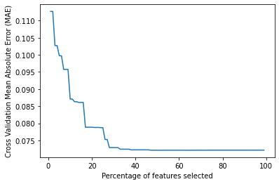

```python
optimal_percentile_ind = np.where(results == results.min())[0][0]
print("Optimal percentile of features: {}".format(percentiles[optimal_percentile_ind]), "\n")
optimal_num_features = int(percentiles[optimal_percentile_ind]*len(X.columns)/100) #int(97*0.41)=39
print("Optimal number of features: {}".format(optimal_num_features), "\n")

# Plot percentile of features VS. cross-validation scores
import pylab as pl
pl.figure()
pl.xlabel("Percentage of features selected")
pl.ylabel("Cross Validation Mean Absolute Error (MAE)")
pl.plot(percentiles,results)
```

```python
from sklearn import metrics
def measure_performance(X, y, model, metric = metrics.mean_absolute_error):
    y_pred = model.predict(X)
    score = metric(y, y_pred)
    return score
```

```python
fs = feature_selection.SelectPercentile(feature_selection.f_regression , percentile=percentiles[optimal_percentile_ind])
X_train_fs = fs.fit_transform(X_train, y_train)
linreg = LinearRegression()
linreg.fit(X_train_fs, y_train)
X_test_fs = fs.transform(X_test)
mae_train = measure_performance(X_train_fs, y_train, linreg)
mae_test = measure_performance(X_test_fs, y_test, linreg)
print('[Feature Selection]')
print("MAE on Training Data: %.4f" %mae_train)
print("MAE on Test Data: %.4f" %mae_test)
```

```
[Feature Selection]
MAE on Training Data: 0.0721
MAE on Test Data: 0.0722
```

#### Try Regularization in linear regression

```python
from sklearn.model_selection import KFold
```

```python
def calc_params(X, y, clf, param_values, param_name, K):

    # Convert input to Numpy arrays
    X = np.array(X)
    y = np.array(y)

    # initialize training and testing score arrays with zeros
    train_scores = np.zeros(len(param_values))
    test_scores = np.zeros(len(param_values))

    # iterate over the different parameter values
    print('alpha\t RMSE_cv(train)\t RMSE_cv(test)')

    for i, param_value in enumerate(param_values):
        #print(param_name, ' = ', param_value)

        # set classifier parameters
        clf.set_params(**{param_name:param_value})

        # initialize the K scores obtained for each fold
        k_train_scores = np.zeros(K)
        k_test_scores = np.zeros(K)

        # create KFold cross validation
        cv = KFold(n_splits=K, shuffle=True, random_state=0)

        # iterate over the K folds
        j = 0
        for train, test in cv.split(X):
            # fit the classifier in the corresponding fold
            # and obtain the corresponding accuracy scores on train and test sets
            clf.fit(X[train], y[train])
            k_train_scores[j] = np.sqrt(measure_performance(X[train], y[train], clf, metric = metrics.mean_squared_error))
            k_test_scores[j] = np.sqrt(measure_performance(X[test], y[test], clf, metric = metrics.mean_squared_error))
            j += 1

        # store the mean of the K fold scores
        train_scores[i] = np.mean(k_train_scores)
        test_scores[i] = np.mean(k_test_scores)

        print('{:.4f}\t {:.4f}\t\t {:.4f}'.format(param_value, train_scores[i], test_scores[i]))

    # plot the training and testing scores in a log scale
    plt.plot(param_values, train_scores, label='RMSE-Train(cv)', alpha=0.4, lw=2, c='b')
    plt.plot(param_values, test_scores, label='RMSE-Test(cv)', alpha=0.4, lw=2, c='g')
    plt.legend(loc='lower right')
    plt.xlabel(param_name + " values")
    plt.ylabel("Mean Cross Validation RMSE")

    # return the training and testing scores on each parameter value
    return train_scores, test_scores
```

#### a. Ridge Regression

```python
from sklearn.linear_model import Ridge
ridge = Ridge()
```

```python
# Let's create an evenly spaced range of numbers in a specified interval
alpha_ridge = np.linspace(0.001, 10.0)
```

```
Ridge Regression

alpha	 RMSE_cv(train)	 RMSE_cv(test)
0.0010	 0.0956		 0.0958
0.2051	 0.0956		 0.0958
0.4091	 0.0956		 0.0958
0.6132	 0.0956		 0.0958
0.8172	 0.0956		 0.0958
1.0213	 0.0956		 0.0958
1.2254	 0.0956		 0.0958
1.4294	 0.0956		 0.0958
1.6335	 0.0956		 0.0958
1.8376	 0.0956		 0.0958
2.0416	 0.0956		 0.0958
2.2457	 0.0956		 0.0958
2.4497	 0.0956		 0.0958
2.6538	 0.0956		 0.0958
2.8579	 0.0956		 0.0958
3.0619	 0.0956		 0.0958
3.2660	 0.0956		 0.0958
3.4700	 0.0956		 0.0958
3.6741	 0.0956		 0.0958
3.8782	 0.0956		 0.0958
4.0822	 0.0956		 0.0958
4.2863	 0.0956		 0.0958
4.4903	 0.0956		 0.0958
4.6944	 0.0956		 0.0958
4.8985	 0.0956		 0.0958
5.1025	 0.0956		 0.0958
5.3066	 0.0956		 0.0958
5.5107	 0.0956		 0.0958
5.7147	 0.0956		 0.0958
5.9188	 0.0956		 0.0958
6.1228	 0.0956		 0.0958
6.3269	 0.0956		 0.0958
6.5310	 0.0956		 0.0958
6.7350	 0.0956		 0.0958
6.9391	 0.0956		 0.0958
7.1431	 0.0956		 0.0958
7.3472	 0.0956		 0.0958
7.5513	 0.0956		 0.0958
7.7553	 0.0956		 0.0958
7.9594	 0.0956		 0.0958
8.1634	 0.0956		 0.0958
8.3675	 0.0956		 0.0958
8.5716	 0.0956		 0.0958
8.7756	 0.0956		 0.0958
8.9797	 0.0956		 0.0958
9.1838	 0.0956		 0.0958
9.3878	 0.0956		 0.0958
9.5919	 0.0956		 0.0958
9.7959	 0.0956		 0.0958
10.0000	 0.0956		 0.0958
```

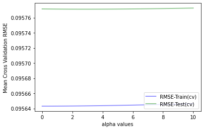

```python
print('Ridge Regression\n')
train_scores, test_scores = calc_params(X_train, y_train, ridge, alpha_ridge, 'alpha', 5)
```

```python
bestIndex = np.where(test_scores == test_scores.min())[0][0]
best_alpha_ridge = alpha_ridge[bestIndex]
print('{:.4f}'.format(best_alpha_ridge))
```

```
2.8579
```

#### The best ridge regularization coefficient maybe around 2.8579 with lowest RMSE cross-validation scores.

```python
# Ridge Regression

# Create linear regression object with a ridge coefficient 2.8579
ridge = Ridge(alpha=best_alpha_ridge)

# Train the model using the training set
ridge.fit(X_train, y_train)

p_train = ridge.predict(X_train) # p_train is the array of predicted training values
rmse_train = np.sqrt(mean_squared_error(p_train, y_train))

# Compute RMSE on the set-aside test data
p_test = ridge.predict(X_test) # predictions on the test instances
rmse_test = np.sqrt(mean_squared_error(p_test, y_test))

#Check overfitting
rige_rmse_overall = rmse_test/rmse_train

method_name = 'Ridge Regression'
print('Method: %s' %method_name)
print('RMSE on training: %.4f' %rmse_train)
print('RMSE on test data: %.4f' %rmse_test)
print('Rige RMSE Overall: %.2f' %rige_rmse_overall)
```

```
Method: Ridge Regression
RMSE on training: 0.0957
RMSE on test data: 0.0967
Rige RMSE Overall: 1.01
```

#### b. Lasso Regression

```python
from sklearn.linear_model import Lasso
lasso = Lasso()
```

```python
# Let's create an evenly spaced range of numbers in a specified interval
alpha_lasso = np.linspace(0.0001, 0.01)
```

```
Lasso Regression

alpha	 RMSE_cv(train)	 RMSE_cv(test)
0.0001	 0.0957		 0.0958
0.0003	 0.0959		 0.0959
0.0005	 0.0961		 0.0961
0.0007	 0.0963		 0.0963
0.0009	 0.0965		 0.0966
0.0011	 0.0968		 0.0969
0.0013	 0.0972		 0.0972
0.0015	 0.0975		 0.0975
0.0017	 0.0978		 0.0979
0.0019	 0.0982		 0.0982
0.0021	 0.0985		 0.0986
0.0023	 0.0989		 0.0989
0.0025	 0.0993		 0.0993
0.0027	 0.0997		 0.0998
0.0029	 0.1002		 0.1002
0.0031	 0.1007		 0.1007
0.0033	 0.1012		 0.1013
0.0035	 0.1018		 0.1018
0.0037	 0.1024		 0.1024
0.0039	 0.1030		 0.1030
0.0041	 0.1036		 0.1036
0.0043	 0.1043		 0.1043
0.0045	 0.1050		 0.1050
0.0047	 0.1057		 0.1057
0.0049	 0.1064		 0.1064
0.0052	 0.1071		 0.1071
0.0054	 0.1078		 0.1078
0.0056	 0.1085		 0.1086
0.0058	 0.1093		 0.1093
0.0060	 0.1101		 0.1101
0.0062	 0.1107		 0.1108
0.0064	 0.1114		 0.1115
0.0066	 0.1121		 0.1122
0.0068	 0.1128		 0.1129
0.0070	 0.1136		 0.1136
0.0072	 0.1143		 0.1144
0.0074	 0.1151		 0.1151
0.0076	 0.1159		 0.1159
0.0078	 0.1167		 0.1167
0.0080	 0.1175		 0.1176
0.0082	 0.1183		 0.1184
0.0084	 0.1192		 0.1192
0.0086	 0.1201		 0.1201
0.0088	 0.1209		 0.1210
0.0090	 0.1218		 0.1219
0.0092	 0.1227		 0.1228
0.0094	 0.1236		 0.1236
0.0096	 0.1244		 0.1245
0.0098	 0.1253		 0.1253
0.0100	 0.1261		 0.1261
```

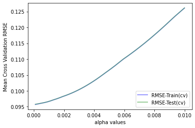

```python
print('Lasso Regression\n')
train_scores, test_scores = calc_params(X_train, y_train, lasso, alpha_lasso, 'alpha', 5)
```

```python
bestIndex = np.where(test_scores == test_scores.min())[0][0]
best_alpha_lasso = alpha_lasso[bestIndex]
print('{:.4f}'.format(best_alpha_lasso))
```

```
0.0001
```

#### The best lasso regularization coefficient maybe around 0.0001 with lowest RMSE cross-validation scores.

```python
# Lasso Regression

# Create linear regression object with a lasso coefficient 0.0001
lasso = Lasso(alpha=best_alpha_lasso)

# Train the model using the training set
lasso.fit(X_train, y_train)

p_train = lasso.predict(X_train) # p_train is the array of predicted training values
rmse_train = np.sqrt(mean_squared_error(p_train, y_train))

# Compute RMSE on the set-aside test data
p_test = lasso.predict(X_test) # predictions on the test instances
rmse_test = np.sqrt(mean_squared_error(p_test, y_test))

#Check overfitting
lasso_rmse_overall = rmse_test/rmse_train

method_name = 'Lasso Regression'
print('Method: %s' %method_name)
print('RMSE on training: %.4f' %rmse_train)
print('RMSE on test data: %.4f' %rmse_test)
print('Lasso RMSE Overall: %.2f' %lasso_rmse_overall)
```

```
Method: Lasso Regression
RMSE on training: 0.0957
RMSE on test data: 0.0967
Lasso RMSE Overall: 1.01
```

#### c. Stochastic Gradient Descent Regressor

```python
# SGD is very senstitive to varying-sized feature values. So, first we need to do feature scaling.
from sklearn.preprocessing import StandardScaler

scaler = StandardScaler()
scaler.fit(X_train)
X_train_s = scaler.transform(X_train)
X_test_s = scaler.transform(X_test)
```

```python
from sklearn.linear_model import SGDRegressor
from sklearn.model_selection import GridSearchCV

sgdreg = SGDRegressor()
parameters = {'penalty': ['l1', 'l2'], 'alpha': np.linspace(0.0001, 10)}
gs = GridSearchCV(sgdreg, parameters)
gs.fit(X_train_s, y_train)
gs.best_params_, gs.best_score_
```

```
({'alpha': 0.0001, 'penalty': 'l1'}, 0.6247248768396088)
```

```python
# Stochastic Gradient Descent Regressor

sgdreg = SGDRegressor(penalty='l1', alpha=0.0001)

# Train the model using the training set
sgdreg.fit(X_train_s, y_train)

p_train = sgdreg.predict(X_train_s) # p_train is the array of predicted training values
rmse_train = np.sqrt(mean_squared_error(p_train, y_train))

# Compute RMSE on the set-aside test data
p_test = sgdreg.predict(X_test_s) # predictions on the test instances
rmse_test = np.sqrt(mean_squared_error(p_test, y_test))

#Check overfitting
sgdreg_rmse_overall = rmse_test/rmse_train

method_name = 'Stochastic Gradient Descent Regressor'
print('Method: %s' %method_name)
print('RMSE on training: %.4f' %rmse_train)
print('RMSE on test data: %.4f' %rmse_test)
print('SGD RMSE Overall: %.2f' %sgdreg_rmse_overall)
```

```
Method: Stochastic Gradient Descent Regressor
RMSE on training: 0.0959
RMSE on test data: 0.0970
SGD RMSE Overall: 1.01
```

#### d. Elastic Net Regression

```python
from sklearn.linear_model import ElasticNet
```

```python
sgdreg = SGDRegressor()
parameters = {'penalty': ['elasticnet'], 'l1_ratio': np.linspace(0,1), 'alpha': np.linspace(0.0001,10)}
gs = GridSearchCV(sgdreg, parameters)
gs.fit(X_train_s, y_train)
gs.best_params_, gs.best_score_
```

```
({'alpha': 0.0001, 'l1_ratio': 1.0, 'penalty': 'elasticnet'},
 0.6254916975399396)
```

```python
# Elastic Net Regression

elastic = ElasticNet(alpha=0.0001, l1_ratio=0.7143)

# Train the model using the training set
elastic.fit(X_train, y_train)

p_train = elastic.predict(X_train) # p_train is the array of predicted training values
rmse_train = np.sqrt(mean_squared_error(p_train, y_train))

# Compute RMSE on the set-aside test data
p_test = elastic.predict(X_test) # predictions on the test instances
rmse_test = np.sqrt(mean_squared_error(p_test, y_test))

#Check overfitting
elastic_rmse_overall = rmse_test/rmse_train

method_name = 'Elastic Net Regression'
print('Method: %s' %method_name)
print('RMSE on training: %.4f' %rmse_train)
print('RMSE on test data: %.4f' %rmse_test)
print('Elastic Net RMSE Overall: %.2f' %elastic_rmse_overall)
```

```
Method: Elastic Net Regression
RMSE on training: 0.0957
RMSE on test data: 0.0967
Elastic Net RMSE Overall: 1.01
```

```python
# Simple Linear Regression
linreg = LinearRegression()

# Train the model using the training set
linreg.fit(X_train, y_train)
p_train = linreg.predict(X_train) # p_train is the array of predicted training values
rmse_train = np.sqrt(mean_squared_error(p_train, y_train))

# Compute RMSE on the set-aside test data
p_test = linreg.predict(X_test) # predictions on the test instances
rmse_test = np.sqrt(mean_squared_error(p_test, y_test))

#Check overfitting
linear_rmse_overall = rmse_test/rmse_train


method_name = 'Simple Linear Regression'
print('Method: %s' %method_name)
print('RMSE on training: %.4f' %rmse_train)
print('RMSE on test data: %.4f' %rmse_test)
print('Simple Linear RMSE Overall: %.2f' %linear_rmse_overall)
```

```
Method: Simple Linear Regression
RMSE on training: 0.0957
RMSE on test data: 0.0967
Simple Linear RMSE Overall: 1.01
```

```python
print('Simple Linear RMSE Overall: %.2f' %linear_rmse_overall)
print('Rige RMSE Overall: %.2f' %rige_rmse_overall)
print('Lasso RMSE Overall: %.2f' %lasso_rmse_overall)
print('SGD RMSE Overall: %.2f' %sgdreg_rmse_overall)
print('Elastic Net RMSE Overall: %.2f' %elastic_rmse_overall)
```

```
Simple Linear RMSE Overall: 1.01
Rige RMSE Overall: 1.01
Lasso RMSE Overall: 1.01
SGD RMSE Overall: 1.01
Elastic Net RMSE Overall: 1.01
```